# Historical Dynamics_Why States Rise and Fall.Turchin2003.历史动力学_国家为何兴衰

这项分析蕴含的意义令人震惊，但是在得出任何能够产生广泛影响的结论之前，我们需要研究其他数据集以核实这些研究结果。显而易见，第一个值得研究的地域是上一个千年里的其他欧洲国家。我没有找到其他数据集能够在数量和时长上与里格利及其合著者构建的数据集相媲美，不过麦克伊韦迪和琼斯绘制的人口地图集虽然略逊一筹，但它的概述极有价值。从很多角度看，这本地图集以国家为单位，极其出色地汇编了长期人口动态，不过我认为它存在着作者对波动程度重视不足的缺陷。举例来说，我们进行客观的检验式研究时，发现麦克伊韦迪和琼斯认为英格兰的人口数量在整个17世纪持续增长（尽管其增长率不断下降）：英格兰的人口在公元1600年、公元1650年和公元1700年分别为425万人、500万人和575万人。然而，里格利及其合著者重建的人口数据表明，在这一时期，所有人口增长出现在前半程（人口规模从505万人增长至583万人），而且事实上人口规模在18世纪初还小幅下降（在1710年下降到573万）——里格利等人的研究晚于麦克伊韦迪和琼斯出版人口地图集的时间。不过，麦克伊韦迪和琼斯的保守主义也有可取之处：他们暗示人口数量出现剧变时，很可能表明有极其可靠的历史数据支撑这些观点。

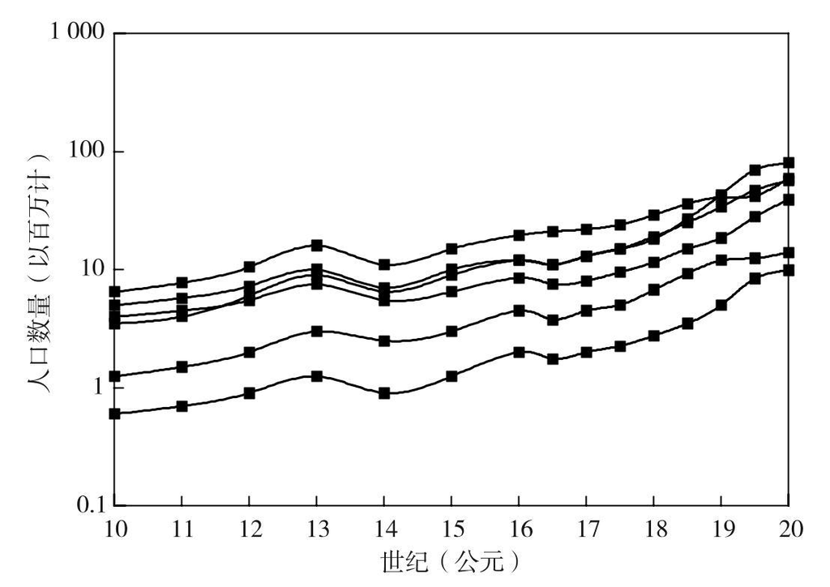

图8.2 公元1000—2000年部分欧洲国家的人口数量

注：这些国家为法国、意大利、西班牙、德国、捷克斯洛伐克和葡萄牙（我们按照这些国家在公元1000年时的人口规模，从大至小对它们进行了排列）。2000年美国人口普查局的数据对麦克伊韦迪和琼斯提供的数据进行了补充。

在图8.2中，我分别为西欧最大的四个国家，以及两个分别位于这四个国家西南角和东部且规模略小的国家重建了麦克伊韦迪和琼斯提出的人口动态轨迹。尽管我们进行形式分析时使用的数据不够详尽，但我们可以看到，从英国的研究结果中找到的一般模式在其他欧洲国家的研究中也有所体现，也就是说，上一个千年里表现出人口持续增长的趋势，同时围绕这个趋势出现了三个长周期，即人口增长在14世纪、17世纪和20世纪末放慢了速度或掉转方向。只有法国的人口没有在17世纪下降，而这是由前文提到的麦克伊韦迪和琼斯的保守主义造成的（下一章研究了更加详细的法国人口数据，会再次涉及这个问题）。此外，对法国南部和北部的动态变化取平均值进一步掩饰了变化的程度。譬如，有历史记录清晰地表明，法国南部的人口在1680年至1750年间有所减少（Le Roy Ladurie，1974），而北部人口规模下降的时间比这更早（如请参见Reinhard et al.，1968，图13）。当时（即公元2000年），所有欧洲国家的出生率都低于死亡率。其中有一半国家，外来移民不足以弥补出生率与死亡率之间的缺口，实际人口数量在下降（请参见美国人口普查局的数据）。

现在我的关注点要转向欧亚大陆的另外一端，即中国的人口动态。中国的情况错综复杂。一方面，中国的中央集权（当它确实存在时）为了达到征税的目的开展了细致入微的人口普查。另一方面，腐败或懒散的政府官员往往会伪造或篡改人口数据（Ho，1959）。应税家庭与实际人口之间的转换系数往往无人知晓。更糟糕的是，各个王朝的转换系数可能不尽相同。国家掌控下的区域也在不断变化。最后，一旦王朝陷入乱世动荡，往往会因为人口统计方面的变动（如人口死亡和移居国外）或国家难以控制国民也无法对他们一一记录在案，而难以确定应税家庭的数量是否下滑。因此，专家对这些问题的看法存在一定程度的争议（Ho，1959；Durand，1960；Song et al.，1985）。然而，他们的争议主要涉及人口的绝对水平，而且他们对于人口密度相对变化的看法高度一致（当然，这是我们研究的主要问题）。从根本上说，中国的人口规模在政治稳定时期持续扩张，在动荡时期收缩（有时会直线下降）。因此，人口的变动清晰地反映出中国的“王朝循环”（Ho，1959；Reinhard et al.，1968）。

赵谢二人（Chao and Hsieh，1988）发布的研究成果是对中国人口动态轨迹最详尽的研究。他们按照不规则的时间间隔估算了中国的人口数量。为了使这些数据适用于时间序列分析，我以每10年为间隔，利用幂指数核插补了赵谢二人的数据，形成更加平滑的动态轨迹，并按照10年的时间间隔对它提取子样本。显然这个轨迹并不稳定，而且至少包括两个陡峭的阶梯状变化：（1）在11世纪之前，人口的峰值在5000万左右；（2）从12世纪至18世纪初，人口的峰值增长了一倍，达到约1亿；（3）自18世纪开始，人口快速增长，于19世纪达到4亿，并在20世纪超过10亿。我们已经了解了从第一个时期向第二个时期转换的潜在机制。在11世纪之前，中国的国家重心一直位于北方，定居于南方的人口非常稀少。到了宋朝，南方的发展速度赶上北方，并进而超越后者（如请参见Reinhard et al.，1968，图14、图115）。

我放弃了第三个阶段（因为它最经不起去趋势操作的检验），转而重点研究了公元前200年至公元1710年这个时间段，从中获得192个数据点（它们的取样间隔是10年）。如果我们将这些数据序列划分为三个规模相当的数据片段，那么第二个数据片段恰好将人口峰值达到5000万的时间段与人口峰值达到1亿的时间段分割开（请参见图8.3）。看起来按6.4个世纪的时间间隔将数据序列划分为数据片段是合理的，因为每个数据片段都应该足够长，可以容纳多个振荡（=“数据点”）。

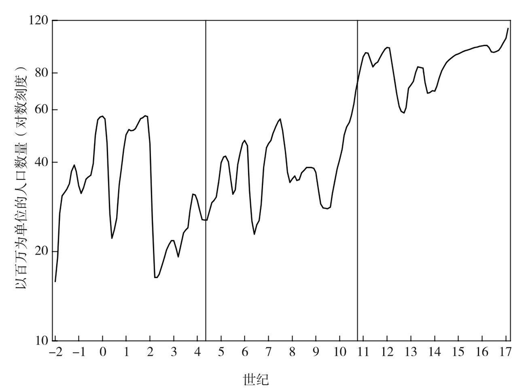

图8.3 公元前200年至公元1710年中国的人口动态

注：垂直线表示数据序列的分割点。

资料来源：Chao and Hsieh（1988）。

此外，振荡的周期性表现出错综复杂的本质，看起来很多振荡都相互重叠。因此在第二个和第三个数据序列片段中同时存在两个振荡：其中较短的振荡持续了1.3~1.5个世纪，另外一个较长的振荡延续了三四个世纪。鉴于我们从这三个数据序列中估算出的振荡周期性差别很大，所以我们应该对这些研究结果持保留态度，即证明中国数据具有周期性的证据不够有力。相反，我们分别利用复制数据序列和时间延迟选择进行研究后，都有充分的证据表明确实存在二阶动态（请参见表8.1）。总之，尽管对中国人口数量的估算结果存在不确定性，我们应该谨慎地解读这项分析得出的结果，但它仍然提供了极其重要的证据，确认西欧数据中发现的二阶振荡确实存在。

对其他地区重建人口的研究不如西欧和中国的研究这么完善，因此不适于开展形式化的数据序列分析。这方面的一个范例是惠特莫尔等人（Whitmore et al.，1993）对美索不达米亚、埃及、尤卡坦半岛和墨西哥中部高原的人口动态提供的极为有趣的数据。这些数据表明，人口数量的典型状态不是停滞不前或缓慢增长，而是振荡，即在增长期里穿插着不少下滑期（有时下降的幅度非常剧烈）。遗憾的是，这些数据的取样频率不足以开展时间序列分析。有意思的是，惠特莫尔等人认为人类动态的“变化速度”随历史进程大幅上升，因此在远古时代，人口动态的振荡（他们称之为“波动”）极其缓慢，需要数千年的时间才能完成整个过程，而到了近代，这个过程只需要几个世纪就完成了。我对这一研究总结的疑问在于：它很可能是因为我们对历史认识不全面而产生的“人为结果”。由于我们对近代史的了解远远超过对远古的了解，所以比起对近代历史的研究，我们研究遥远的过去时很可能会“错过”更多人口下降的情况。这种系统性偏差会产生同样的模式，即振荡显著加速。我们可以用玛雅人口史来佐证这一点。第一个研究玛雅文明毁灭过程的考古学家甚至没有怀疑过，在玛雅社会发展史的某个时间点，它长期保持着人口密度极高的状态。我们最早了解到的情况是务农者在热带雨林中开垦出一些临时农田，其中分布着不少举办仪式的中心。后来的考古工作表明，排除合理的怀疑以外，玛雅社会达到人口峰值（或很可能多次达到人口峰值）时，在以相当集约的方式大面积耕种。相应地，我们重建其早期动态后，发现玛雅人口经历了极其漫长的缓慢增长期（这个时期超过了1000年），随后迅速崩溃（这个时期为一个世纪）。近期的证据显示，在危地马拉和佩腾的高地上多次出现中央集权和国家崩溃的往复循环（Culbert and Rice，1990）。由此我们可以清晰地看到玛雅的人口史极其复杂。我们必须等到有更多考古数据和更完善的研究方法才能按照本书探讨的研究方法开展数据序列分析。

### 8.3.2 考古数据

目前在历史（或史前）人口动态研究中存在着诸多争议，而考古研究法为学界平息这些争议带来了希望。利用考古数据估算人口的研究方法存在一个普遍问题，即考古数据属于间接数据，来自人类留下的实体记录，譬如在大多数情况下，这些数据记录了某个特定时间段的房屋数量或定居点数量。人们还可以利用花粉数量来计算粮食产量，进而估算人类密度。所有这些案例都面对着一个问题：如何将考古记录中衡量人类活动的定量结果转化成人口数量。譬如，如果我们估算某个时间段出现了多少建筑物，那么还需要了解每座建筑里平均居住几个人。我要强调的是，这个问题并非无法解决。事实上，种群生态学方面的研究人员常常会依靠人口密度的指标开展研究，这些指标甚至与人口密度本身呈非线性相关（这方面的一个著名范例是猞猁皮毛收益的10年周期的数据）。此外，我们感兴趣的首要问题是相对人口波动。比起绝对人口密度，与相对人口波动有关的数据更容易记录在案。

采用考古研究法的一个显著优势是它们能提供更客观的途径来重建人口史。毫无疑问，这些方法也存在偏差，需要在实际应用中反复斟酌（Dewar，1991;Curet，1998）。不过总体来说，它们的主观性和臆测程度已经减少了不少。

正如我在第8.2节阐述的那样，要想达到我们的研究目的，人口史研究的取样间隔不能超过50年。因此，考古文献中发布的人口估算数据多半都不适用于我们的分析。譬如，有一组很有意思的数据库比较接近本书的研究要求。它重建了中东地区德赫洛兰（Deh Luran）平原的人口发展历史（Dewar in Neeley and Wright，1994，第211页）。研究结果表明，至少出现过三次巨大的人口密度振荡（即峰谷比达到10倍），但它的取样间隔为200~300年，对于形式分析来说间隔过大。

不过，目前已经出现许多取样率开始接近理想水平的数据集。第一个范例是罗马帝国人口史，在过去几十年里，它所引发的论战一直如火如荼（Scheidel，2001）。人们关注的是人口减少在罗马帝国崩溃中发挥了什么作用，但其中存在一个棘手的问题，即最早表明人口减少的证据出现在罗马共和国的最后几十年（Brunt，1971）。李维特（Lewit，1991）最近发布了一个相当令人注目的数据集，使人们对这个问题产生了新的认识（请参见图8.4）。事实证明在罗马帝国时代出现过两次放弃定居地的情况，分别出现在3世纪和5世纪。由于实际使用的定居地在考古挖掘出来的定居地中的比重发生变化，低估了人口变化的幅度，所以人口规模在3世纪的下降程度（以及在4世纪的中兴程度）必然极大。第9.1节进一步深入探讨了这些数据。

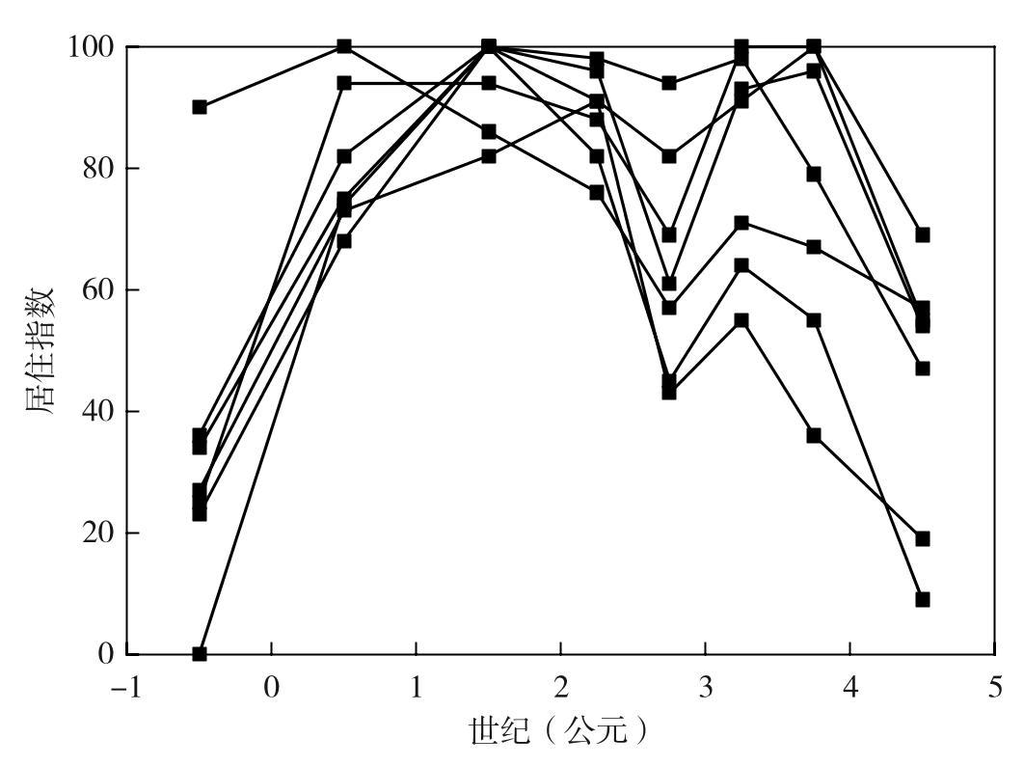

图8.4 罗马帝国西部的七个地区各个时期被考古挖掘的实际定居点的相对比例

注：这七个地区包括英国、比利时、北高卢、南高卢、意大利、西班牙北部、西班牙南部。

资料来源：Lewit（1991）。

另外一组遗址居住数据与“新世界”（New World）有关。哈利（Hally，1996）发布了在格鲁吉亚发掘出的公元1000—1600年平台式土墩的相关数据，表明这个地区的西北部出现过三次振荡，但东南部只出现过两次振荡。由于本书篇幅所限，我无法提供更多此类案例。不过我们需要提及的最后一组数据集也来源于新世界（Varien，1999），因为它的时间精度很高。这些数据描述了（科罗拉多州）梅萨维德国家公园（Mesa Verde）的原木。由于这里气候干燥，所以用来建造房屋的原木可以保存几个世纪（顺便说一句，这些原木会被反复用来建造房屋）。考古学家可以利用树木年代学的研究方法来准确地确定原木的砍伐时间。图8.5展示了在某一个遗址（即威瑟利尔·梅萨）找到的原木的砍伐时间分布情况。这些数据表明该地区经历过四次建屋活动突然爆发的时期（分别出现于7世纪、9世纪、11世纪和13世纪），暗示这些时期经历了人口快速增长。建屋活动暴增后随之而来的往往是建屋活动的停滞期（分别出现在公元700年、公元900年和公元1300年之后。只有在11世纪和13世纪高峰之间的12世纪期间持续存在程度较低的建屋活动）。遗憾的是，我们不能利用标准的NLTSM法来分析这些数据，因为产生这些数据的流程在结构上完全不同于常规的人口研究流程（事实上，我们对这个地区的人口增长期有所了解，但数据集中没有任何关于人口减少的数据）。不过，我们可以对数据进行转换后计算ACF来改善其偏态（请参见图8.5中的插图）。显然ACF表明数据中有一个持续了两个世纪的周期。

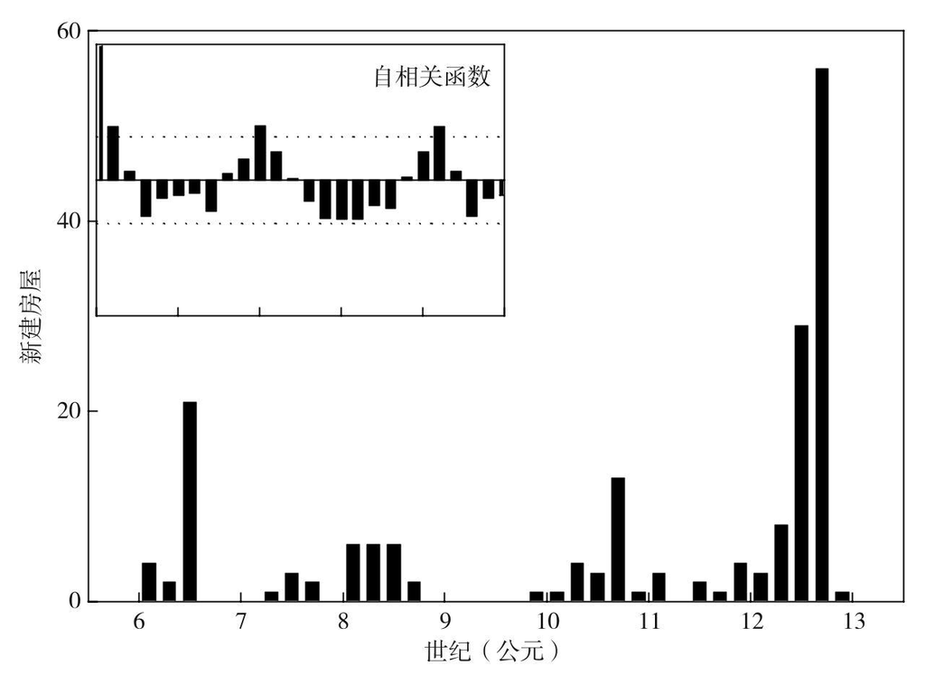

图8.5 威瑟利尔·梅萨的新建房屋

注：ACF，平方根转换数据的自相关函数（滞后单位以世纪计）。

## 8.4 人口动态和政治动荡

尽管我们发现人类的人口数据中存在长期振荡，与人口-财政模型得出的结论基本保持一致，但其他社会人口过程也可能产生同样的实证模式。如果可以通过历史记载来核查人口波动与政治动荡之间的关系是否符合人口-结构理论预测的模式，直接检验这个理论的预测成效，那么会更圆满地达到我们的研究目的。朱敬一和罗纳德·李（Chu and Lee，1994）发表过一篇非常有意思的文章来探讨这个问题，我已经在研究中国王朝更替的模型时讨论过它。这两位学者分析了赵谢二人（Chao and Hsieh，1988）提出的中国人口时间序列，以及分别代表农民起义和战争爆发率的两个虚拟变量。如果爆发了起义（或战争），那么虚拟变量的值为1，否则它们的值为0。朱敬一和罗纳德·李在此基础上增加了一个预测变量：温度时间序列。

为了从形式上研究人口动态与政治动荡之间的互动效应，我拓展了第8.3.1节对中国数据所做的非线性时间序列分析，发现用“世代”做时标时，中国人口动态的过程阶数明显为二阶（或更高）。现在我希望检验的假设是，政治动荡是驱动二阶振荡的内生变量。如果这个假说正确无误，那么我们会发现政治动荡对人均人口变化率产生了深刻的影响。

我根据人口的人均变化率调整了一系列模型。人口的人均变化率定义为r<sub>t</sub>≡ln(N<sub>t</sub>/N<sub>t-</sub>)。如果用同样的一般形式来表示它的特点，那么其方程式如下：

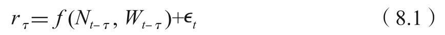

其中W<sub>t</sub>是政治动荡指数。李四光按5年的时间间隔取样计算了内战爆发率，而人口数据的取样时间间隔为10年。要使这两组数据集具有共同的时间精度，我利用幂指数核回归方法（其带宽h=10年）使李四光的指数变得更加平滑，同时按照10年的间隔对这条产生的新曲线重新取样，由此得到变量W<sub>t</sub>（t=公元前200年，公元前190年……公元1700年，公元1710年）。换言之，我对内战数据和人口数据采取了相同的处理方式（请参见第8.3.1节）。

由于不知道方程式8.1中f(·)的函数形式，所以我利用博克斯和德雷珀（Box and Draper，1987）的响应面法（Response Surface Methodology，RSM）建立了一个近似函数。响应面法是修正后的多项式近似函数，其中预测变量（这个方程式中的预测变量为N<sub>t-</sub>和W<sub>t-</sub>）受制于Box-Cox转换。有清晰的证据表明存在曲线效应（请参见下文），因此我利用二次多项式来粗略描述f(·)。这项分析将公元前200年至公元1710年的整个时间序列划分为三个长度相同的数据片段，每个片段中包括64个数据点（这与第8.3.1节中的研究过程完全相同）。它降低了不稳定性的影响，还使我们有条件检验人口动态与政治动荡之间的关系是否会随着时间的推移而发生变化。最后，为了确保滞后基数选择哪个具体数值不会对研究结果造成不当影响，我分别分析了=20年和=30年的情况。

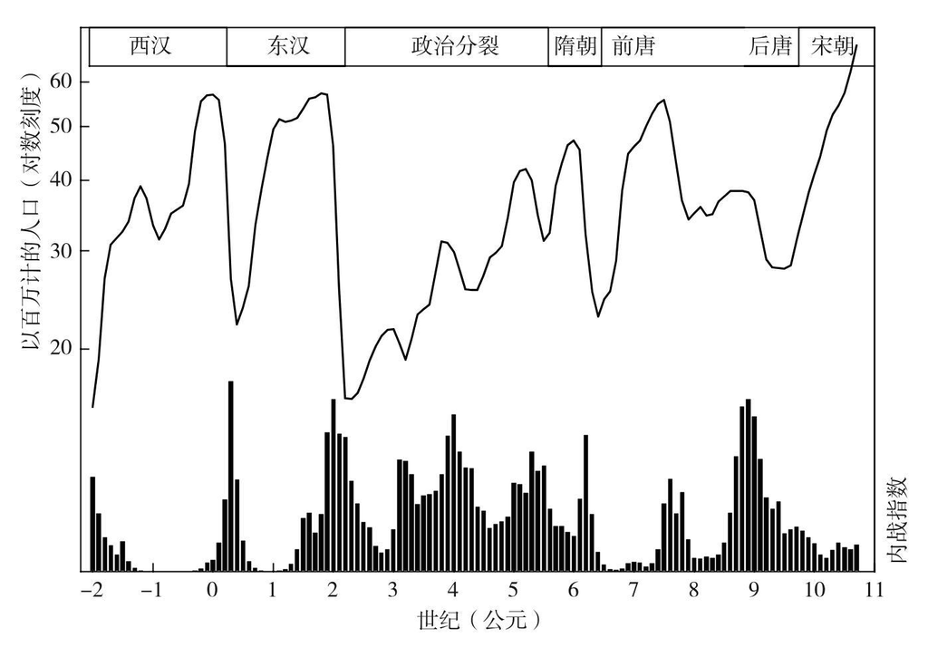

图8.6 公元前200—公元1070年中国的人口动态（用曲线表示）和政治动荡（用条状图表示），顶部栏列出了各个王朝

无论选择20年还是30年，政治动荡在所有这三个时间段里都对人口动态产生了极其显著的影响（请参见表8.2）。人口密度制约和政治动荡结合起来，能解释60%的r<sub>t</sub>变化。这一结果的方向（这里指正或负。——译者注）符合理论预测（请参见图8.7）。

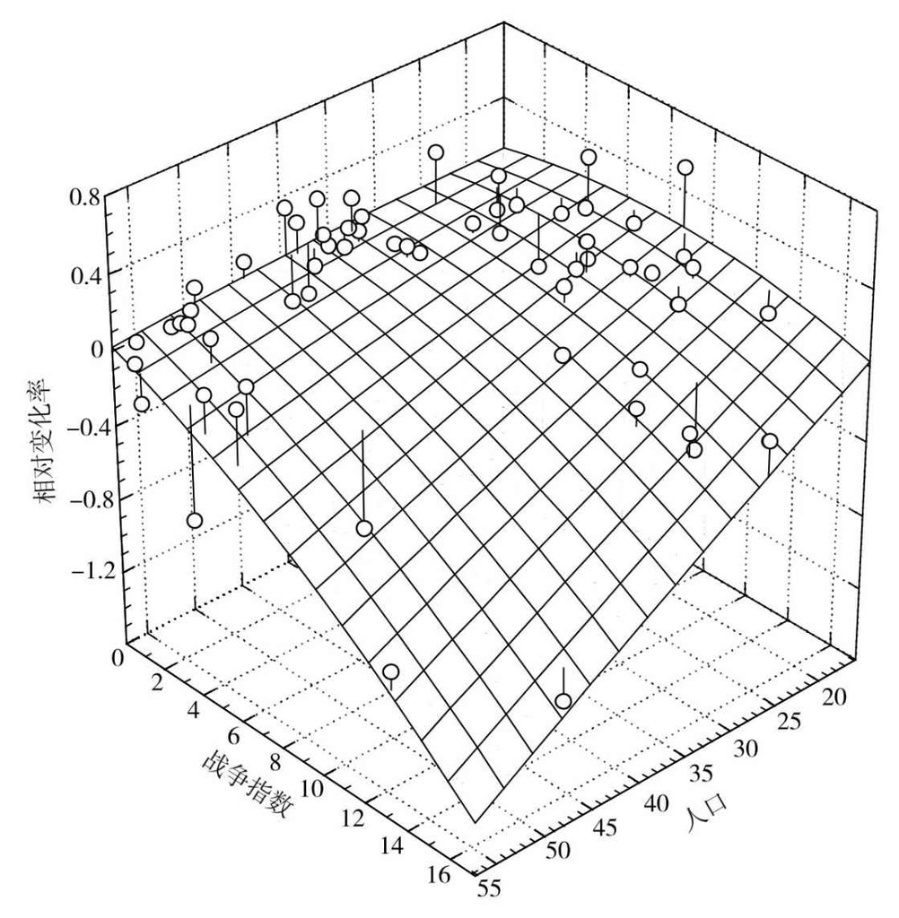

图8.7 在第一个时期（公元前200—公元430年），中国的人口密度和政治动荡对人口变化率产生的影响

表8.2 适用于研究人口变化率和政治动荡指数的模型中的确定系数

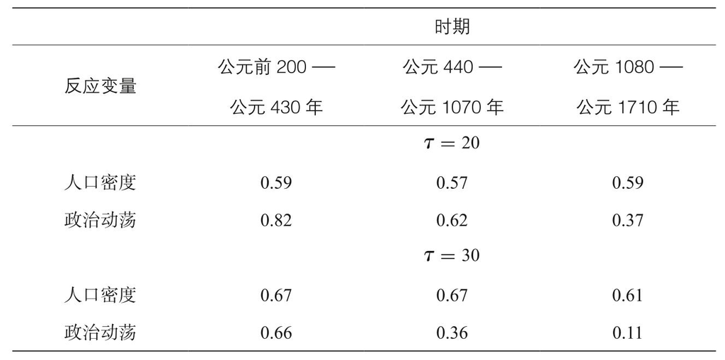

人口密度对人口变化率产生了负面影响，反映了人口动态的基本密度制约模式。政治动荡也对人口增长产生负面影响。有意思的是，如同具有统计学意义的交互项反映的那样，人口密度和政治动荡产生的影响具有协同性。图8.7清晰地展示了这一效应：如果人口密度和政治动荡程度都很高，那么人口下降幅度更明显。

我将政治动荡作为反应变量进行了同样的分析（我对W<sub>t</sub>进行了对数转换，使数据的分布更加正态）。这个模型能够解释的变化的比重从最早的时期到最近的时期依次降低（请参见表8.2）。时间点t-的人口密度对时间点t的政治动荡产生了正影响（请参见图8.8）。政治动荡（W<sub>t-</sub>）过去的值也对当下的政治动荡（W<sub>t</sub>）产生了正影响（请参见图8.8）。

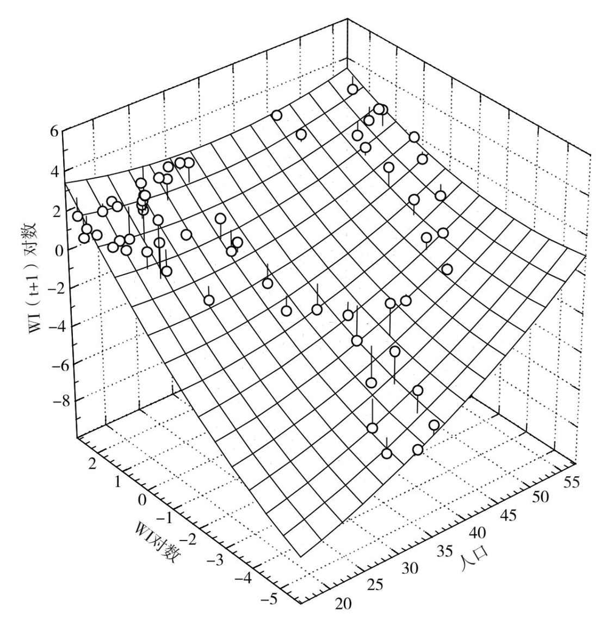

图8.8 在第一个时期（公元前200—公元430年），中国的人口密度和过去的政治动荡对当前的政治动荡所产生的影响

总而言之，对中国数据的分析在实证层面有力地支持了内生版本的人口-结构模型。人口对政治动荡的影响以及政治动荡对人口的影响都得到了数据的证实。它们的确定系数（coefficients of determination）很高，通常都超过了50%（第三个时期中N对W产生影响的确定系数不在此列）。

## 8.5 总结

●我试图从相关文献中寻找与人口波动有关的可用数据集。这些数据集需至少跨越5个世纪，而且以50年或更短的时间间隔进行取样。我找到了很多与欧洲、中国和北美有关的数据集。其中部分数据是对人口动态进行的历史重建，其他数据则来源于考古数据。

●标准的非线性时间序列分析法表明，在最完善的历史数据集里，强有力的证据表明存在二阶调整（如英格兰和中国）和周期性（如英格兰和梅萨维德国家公园）。所有数据集都体现出一个普遍模式，即振荡（人口增长期后出现人口下降期），而且其特点表现为周期性的程度极其多变。人口下降期的间隔通常为两三个世纪。

●我们观察到的模式与人口-结构理论做出的预测完全吻合（请参见第7.2节）。这个理论还预测出这些振荡多多少少不太规则，平均时长为两三个世纪。因此，以上研究结果从实证层面证实了人口-结构理论的有效性。然而，非正式计算表明，绝大多数将人口规模作为一个主要变量的二阶过程引发的振荡时长与上面预测的振荡时长基本相同，因此很可能也有其他理论能够解释这些模式。

●本章同时分析了有关人口数量和内战爆发率的数据（内战爆发率是代表政治动荡的一个指数），借此直接检验人口-结构模型，平息前文对其有效性的警告。回归分析的结果表明，人口密度对政治动荡产生的影响，以及政治动荡对人口密度的逆向影响都具有极高的统计显著性。根据这些数据调整的时间序列模型通常可以消除大部分不一致（variance）。因此，至少在一个案例中（即公元前200年至公元1710年的中国），我们有直接的定量证据证明人口-结构理论的效力。

# 第9章 案例研究

本书的主题之一是找到客观、严格、缜密的方法来检验各种解释历史动态的理论。我利用这种方法探讨了多个历史动态理论，如地缘政治理论、种群动力学和人口-结构理论。所有这些理论都接受过一次或更多实证检验，而它们顺利通过检验的程度各异。因此，在分别检验这些理论时，看起来它们在实证层面都有一定的合理性。然而，目前尚不清楚我们应该如何将各种模型结合起来解释历史动态的整体情况。我们需要提出观点，而这需要我们略微放松要求，也就是说，我们不能像对待根据这些观点提出的假说那样，对它们进行极其严苛的检验。相应地，作为全书的倒数第二章，本章将改变策略，使用和之前截然相反的研究方法。我重点研究了一些具体案例，并讨论具体机制在各个特定案例中如何运作，不同的机制之间如何相互作用，从而为未来的研究提出哪些更加缜密的假设。

我精选了两个政权作为研究重点：长时段内（从起源到公元1900年）的法国和俄罗斯。这两个案例是从成功的欧洲领土强大帝国中选取的样本（特别是在18世纪和19世纪，它们都是列强俱乐部的成员）。这两个政权都位于欧洲北部平原，虽然法国在欧洲北部平原的最西端，而俄罗斯在与法国遥遥相对的东北部。不过这两个国家的社会、政治和经济走上了迥然不同的发展轨道。因此，将它们进行比较时找到的任何相似之处都可能成为我们总结概括的依据。

我按照下面的架构分析了这两个案例的历史动态。首先，我重点关注了群体的动态，以及与之相关的边境和民族演变等问题。其次，我探究了将人口、社会和政治过程联系起来的长周期。

## 9.1 法国

### 9.1.1 边境起源

罗马边境

在公元元年至公元2000年间，欧洲北部平原的最西端相继被纳入三个政权：罗马帝国、法兰克帝国和法兰西王国（即后来的法兰西共和国）。在“罗马人的征服”之后一直到公元3世纪初，罗马的边境贯穿了现在的比荷卢经济联盟和德国西部（即NED、WGE和SGE的文化区。详情请参见图5.1和附录B），对法国北部和东部（即NFR和EFR）的影响极小。这种局面在多灾多难的3世纪发生了变化。罗马帝国在这一时期经历了漫长的国家崩溃和内战。在这个多事之秋，日耳曼入侵者从罗马边境长驱直入，屡次侵袭罗马高卢地区。法兰克人（Franci）、勃艮第人（Burgundi）和阿勒曼人（Alamanni）这三个群体也联合起来向罗马边境推进，或多或少地渗透进罗马帝国之前的领土（Geary，1988；Wolfram，1997）。因此，NFR和EFR这些地区本身成了罗马边境的组成部分。

相对稳定的公元4世纪使人们获得了短暂的喘息之机（不过这一时期的特点是法兰克人不断向南渗透），“蛮族”重新开始四处狂飙突进。法兰克人不断扩张领土，将大多数NFR地区纳入自己的帝国版图。勃艮第人侵入高卢地区腹地，并在EFR建立了自己的王国，同时阿勒曼人继续向南挺进雷蒂亚（这个地区不在我们的研究范围内）。在公元4世纪和5世纪，宗教“断层线”大幅提升了贯穿NFR和EFR的边境上的冲突强度：罗马高卢地区属于基督教区，而法兰克人和阿勒曼人属于异教徒（法兰克人在公元500年左右皈依了基督教，阿勒曼人在公元7世纪也皈依了基督教）。

法兰克帝国的边疆

法兰克人建立自己的帝国后，NFR仍然处于边境，只是这条边境已经易主其他政权。在公元5世纪，布列塔尼半岛逐渐沦入来自不列颠群岛的凯尔特人（Celtic）的殖民统治。凯尔特人在这里建立了自己的政权，而不受墨洛温王朝法兰克人的约束。因此，塞纳河下游和卢瓦尔河之间的区域成了布列塔尼人的边区。然而，（在公元496年后）布列塔尼人和法兰克人都皈依基督教后，边境上爆发的冲突强度下降，尽管他们分属基督教的不同派别，彼此之间存在明显的宗教差异。法国加洛林王朝曾经短暂地征服过布列塔尼，但无法将自己的军事优势转化为长期掌控政权的能力（Galliou and Jones，1991）。尽管布列塔尼人和法兰克人之间的文明差异不大，但在公元9世纪，这两个民族之间的战争不断升级（Dunbabin，1985，第66页），屡屡相互袭击，居住在塞纳河下游和卢瓦尔河下游之间狭长地带的人口大幅减少。诺曼（Norman）侵略者恰好乘机占领了这个地区（Searle，1988）。

维京人最初的定居点在卢瓦尔河和塞纳河的河口附近。尽管最终他们未能在卢瓦尔河流域彻底安顿下来，但在塞纳河流域的定居地逐步扩大。在9世纪和10世纪，鲁昂和巴黎与卢瓦尔北部之间的地区再次成为局势极其紧张的元民族群“断层线”，集合了宗教、语言和军事压力等多个冲突元素。只有诺尔曼人（在宗教和语言上）被拉丁基督教的元民族群同化之后，边境上的激烈争斗才有所缓和。

总之，从3世纪到10世纪，NFR一直位于主要边境上。起初，它是古罗马长城的组成部分，后来成为法兰克王国的边区。随着各类日耳曼侵略者逐渐被拉丁语系和基督教同化，这个边境的冲突强度在高强度和中等强度之间波动，不过它所处的环境基本保持了连续性。元民族边境理论表明，正是在这个民族大熔锅里，法国完成了民族形成的过程，法兰西民族就此诞生。不过在探讨这个过程之前，让我们先简单回顾一下在与它毗邻的区域NED中发生的诸多事件。

法兰克人的民族形成

NED成为边境的时间较早，不再作为边境存在的时间也早于NFR——早在公元1世纪，它就成为边境；到了8世纪末，加洛林王朝攻占弗里斯人（Frisian）和撒克逊人的居住区并改变他们的信仰后，NED便不再是边境（NED覆盖的区域包括现代的比利时、荷兰和卢森堡三国以及莱茵河以西的德国领土）。因此，NED早于NFR完成了民族形成的过程。在罗马攻击高卢地区之前，NED的居住者是诸多小部落，他们缺少可以提升集体凝聚力的文化机制。公元前1世纪，罗马确定了自己的边境后，这些部落的文化机制承受着选择压力（selective pressure）的重负（Miller，1993）。罗马帝国进入元首制（Principate）时期后，对这个地区施加了巨大的军事压力（罗马长城一直延伸到了NED中部）。而在纷争不断的3世纪和罗马帝国采取帝制（Dominate）的时期，罗马帝国对这一地区的“推力”变成了同样势不可挡的“拉力”。正如前文讨论的那样，拉动因素为不断扩张的社会架构提供了强大的选择压力，因为规模较大的侵略势力要想获得可观的战利品，必须有组织性才有能力洗劫整个城市（在罗马帝国实行帝制时期，各个城市开始修筑自己的防御工事）。此外，公元300年之后，整条边境的宗教阶梯变得极其陡峭：因为罗马帝国全部皈依了基督教，而法兰克人相当虔诚地信仰异教，这是法兰克民族形成过程中重要的统一力量（Miller，1993）。另外一个因素是法兰克人不断演变的政治机制：“长发国王”（Scherman，1987）。在公元300年前，西部的日耳曼人尚未建立起王权制度［这不同于东部日耳曼部落，如哥特（人）］。卡马维人（Chamavi）、查土阿里人（Chattuari）、布鲁克特里人（Bructeri）、阿姆斯瓦里人（Amsivarii）和萨利人（Salii）等不同部落融合在一起，形成了单一的法兰克民族（Geary，1988，第78页）。这与元民族边境理论预测的情况一模一样。总之，法兰克人的民族形成过程与边境模型完全契合。

法国人的民族形成

NFR的大部分土地被墨洛温王朝吞并时，它的民族构成极其多元化。在高卢地区（在民族上非常多样化，但这是另外一个故事），高卢人以外的另外两个族群相互叠加。首先，这里有来自罗马帝国其他属地的殖民者，如曾守护边境并随后定居此地的古罗马军团士兵后裔（Geary，1988，第15页）。其次，部分法兰克人从北部迁到这里。法兰克农民可能是塞纳河以北的主要族群，而且对卢瓦尔河沿岸地区产生了深远的影响。在3世纪至5世纪期间，这个地区处于沉重的殖民统治之下，其原因或许在于它的人口在3世纪下半叶大幅减少。考古研究发现，这一时期有人类活动的遗迹只占到2世纪巅峰时期的45%（Lewit，1991）。北高卢地区的人口在4世纪经历了短暂增长后全面崩溃，甚至低于之前的人口水平。到了公元400年以后，这个地区的住宅只有9%还有人居住（Lewit，1991）。农村地区的人口急剧下降，是元民族边境冲突激烈的典型特征之一。

在5世纪，NFR的西部落入布列塔尼人的殖民统治（Musset，1975，第112页）。9世纪和10世纪之间出现了最后一次大规模民族融合。当时来自斯堪的纳维亚的多个日耳曼民族建立了诺曼底公国（Duchy of Normandy）（Searle，1988）。这些多元化的同种同文化民族相对较快地被共同的宗教（即基督教）和语言［通俗拉丁语逐步演化成诺曼法语——奥依语（langue d’oïl）］所同化。这个进程在诺曼人身上发展得尤为迅速，在两个世纪的时间里就被彻底同化了。法兰克人的语言同化过程花费的时间比较长，法兰克语作为现代荷兰语的前身，一直到11世纪还在许多岛屿上流行使用。布列塔尼人的同化过程最漫长（大部分布列塔尼人直至19世纪才转用法语）。

日耳曼入侵者（即法兰克人和诺曼人）相对较快地被所入侵地区的共同文化同化了，由此提出一系列很有意思的问题。为什么诺曼人这么快就被同化了（整个过程只持续了两个世纪），而布列塔尼人则需要1000多年才完成同样的进程？如第6章讨论的那样，当今的社会学研究认为同化速度取决于社会网络的本质。布列塔尼人的社会网络与NFR地区其他种群的社会网络存在巨大差距吗？诺曼人是否迅速与法兰克人的社会网络建立起密切的联系？人们观察到一个与此相关的现象，即法国南部的语言同化进展极其缓慢。尽管这个地区早在13世纪就被法国人（French）占领了，但三个世纪后，这个地区只有大城市使用法语，大多数居民说的是奥克语（Langue d’oc）。又过了三个多世纪后，直至19世纪末它才刚刚经过语言同化过程的中点。附带说一句，在法兰西王国（以下简称法国）成立后的绝大多数时间里，它都具有多民族性，这也是我称之为“帝国”的原因。即使到了1868年（即我们所研究的历史时段行将结束时），只有三分之一的法国居民把法语当作母语。另外三分之一的居民将它作为第二外语，而剩下三分之一的居民根本不使用法语（Weber，1976）。

到了11世纪，如果我们只关注语言和宗教特点，看起来NFR（不包括布列塔尼地区）的统治者是法兰克伯爵们（尽管他们的祖先不是法兰克人，而是罗马时代的地主）或维京人的后裔（这是一个同质化精英阶层）。然而，这个地区在政治层面并不统一。相反，自从9世纪中期西法兰克国王“秃头查理”（Charles the Bald）打造出纽斯特里亚（Neustria）边区后，很多地区势力前仆后继地在这里崛起并被合并，而且这种局势在10世纪末愈演愈烈（Dunbabin，1985；Bates，1995）。其中最活跃的政权是围绕诺曼底公爵与安茹/巴黎伯爵建立起来的（后者还在987年为自己赢得了法国皇冠，尽管当时这只具有象征意义）。其他攻击性较弱的刚刚成立的政权是由布洛瓦伯爵和布列塔尼公爵建立的（前者获得了香槟地区的控制权）。这类政权如雨后春笋般不断涌现的局势很容易让我们联想到空间边境模型的动态。如果我们有充分的理由进行这种类比，那么诺曼人在11世纪末攻占英格兰的行为可以解读为反流效应（reflux effect）的范例。事实上，在之后的三个世纪里，英格兰的动态或许应该被解读为NFR地区的一个分支。众所周知，诺曼人征服英格兰后，英格兰本土精英这个阶层“被全盘摧毁”，取而代之的是威廉公爵的支持者，他们主要来自法国北部和低地国家。12世纪中期英格兰进入金雀花王朝（Plantagenets）［在法国又称安茹王朝（Angevin dynasty）］后，法国北部再次出现民族融合。说法语的精英阶层和说英语的底层人民相互同化，而这个过程延续了两个多世纪。人们认为金雀花王朝彻底过渡到都铎王朝之后，这个过程才完全结束。

对非精英阶层凝聚力发挥的作用进行回归分析

如果我们对诺曼人占领的英格兰和起源类似的政体——诺曼人占领的西西里岛——的最终命运进行比较，会给我们带来不少启发。这两个政权建立的时间非常接近，而且成立初期的社会政治发展轨迹颇为相似，因此它们常常被视为12世纪欧洲国家成立时比较“早熟”的范例。它们的集权程度在当时看来都高得很不寻常，而且财政基础相当牢固。不过，这两个国家在12世纪之后走上了迥然不同的发展道路。西西里王国（Kingdom of Sicily）迅速衰落（它占据了整个SIT地区），而且历经多位统治者，如德国皇帝、安茹王族、阿拉贡人（Aragonese）、卡斯提尔人（Castilian）以及最终的皮埃蒙特人（Piedmontese）。简而言之，它只是国际政治的客体，而不是主体。相比之下，英格兰自15世纪中叶被驱逐出欧洲大陆以后，在一段时间里地位低微，但最终成为一代列强，甚至在18世纪和19世纪的部分时间里独享霸权。尽管这种比较研究只是比较了单对数据点，存在一定局限性，但仍然反映出社会底层人民的群体感至关重要。公元前1世纪罗马边境移出SIT地区以后，SIT至少在500年的时间里扮演了帝国核心的角色。理论研究表明，这个地区的群体感可能受到了全面压制。相比之下，从5世纪直到11世纪，SBR一直是边境冲突频发的地区。显然在被诺曼人攻占前夕，英格兰早已走上建立一个团结一致且积极扩张的国家之路。这项观察结果促使人们提出一个假说：尽管在短期内，政权动态更多地取决于精英的群体感，但从长期看，它的成败与否很大程度上取决于普通民众的群体感。这仅仅是一个假说，但显然我们可以仔细研究几个案例（即精英阶层和普通民众来自完全不同民族的政权），估算民众群体感如何影响政权的存续时间，以检验以上假说的有效性。

NFR的边境冲突强度动态和法国政权的规模

对于图9.1描绘的轨迹，它最显著的特点是，从长期来看，整个过程极其缓慢。在约8个世纪的时间里，NFR一直受到边境的影响。10世纪以后，边境迅速衰落并最终消失。然而，MFR直到13世纪才出现第一次大幅扩张。法兰西政权持续扩张的势头继续保持了6个世纪，只到近年来才表现出群体感下降的迹象（法国在1870年、1914年和1940年连续受到德国的军事打击，同时失去庞大的海外殖民地）。这些观察结果表明，群体感由盛至衰跨越的时标相当长。事实上，群体感的动态变化似乎比语言同化或宗教同化的动态变化或人口-结构变化过程引发的长周期慢得多。

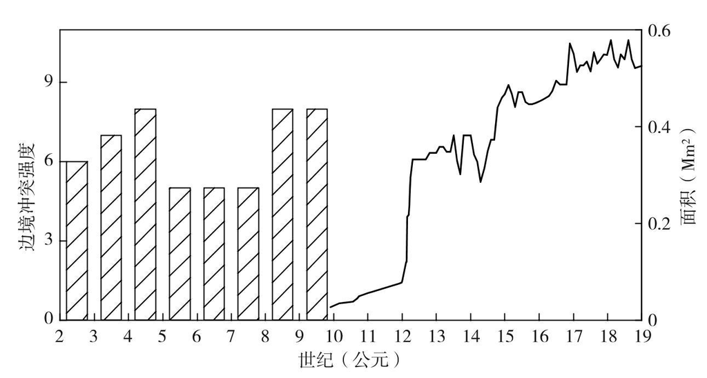

图9.1 NFR的边境冲突强度和法兰西政权的领土面积（不包括海外属地）

### 9.1.2 长期波动

元首统治期的波动

如果第8章讨论的李维特（1991）考古数据确实反映了人口振荡的情况，那么显然罗马帝国统治时期的高卢地区经历过两次振荡，而且纷争不断的3世纪出现的人口下降期将这两次振荡分隔开。以3世纪的人口下降期告终的周期表现出非常清晰的特点（我们将这个周期称作“元首统治期的波动”，因为罗马帝国在这一时期通常被称为“元首统治期”）。（除了高卢南部的罗马帝国行省以外）高卢的绝大多数地区于公元前1世纪并入罗马帝国。在公元1世纪，罗马帝国的边境线分别向北方和东方推进，高卢自此进入漫长的和平繁荣期，人口也因此开始增长（参见图9.2）。

从公元前1世纪到公元2世纪，遗址居住指数增长了3倍，因此实际人口增长的幅度可能更大，因为我们完全有理由假设定居地的规模也在扩大。这种人口增长的模式在罗马帝国的其他地区也有所反映（至少在所有西部行省都是这样的）。根据人口-结构理论，这种不受控制的人口增长会不可避免地导致国家破产，并最终崩溃。历史的实际走向也是如此。在公元2世纪，罗马帝国经历了一波严重的通货膨胀（请参见Fischer，1996，图5.03）。随后国家崩溃，而且在3世纪的大多数时间里，罗马帝国都没有中央政权。导致人口下降的直接原因很多，如饥荒、疾病（如安东尼瘟疫）、波及大多数领土的内讧和蛮族入侵。此外，罗马人在此期间还采用了各种手段控制生育［主要是杀婴，请参见Stark（1996）引用的材料］。不过，我们可以认为，所有这些导致死亡率上升、生育率下降的原因最终都与剧烈的社会政治动荡息息相关。因此，李维特表示，行省人口的下降幅度与它在多灾多难的3世纪经历的战争强度有关。

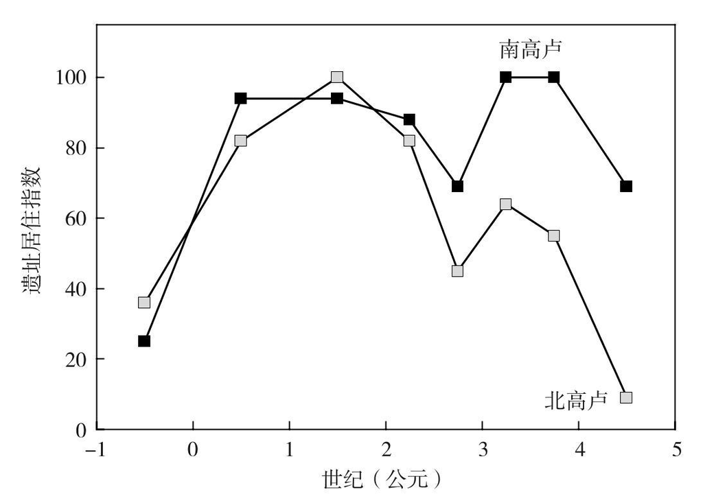

图9.2 罗马高卢地区的人口史

资料来源：Lewit（1991）。

帝制罗马帝国-墨洛温王朝的波动

我们观察北高卢和南高卢的人口变动轨迹时发现它们表现出很有意思的一面：它们在3世纪之前一直保持着同步变化，但在那之后“分道扬镳”（请参见图9.2）。北高卢的遗址居住指数下降幅度超过南高卢，而且在3世纪末重建社会秩序后只出现小幅回升。到了5世纪，北高卢的遗址居住指数进一步下降到更低的水平。引发这种现象的原因可能像上文讨论的那样，北高卢在帝制时期成了罗马边境的一部分，而那里的条件不利于提高人口密度。边境局势越紧张，该地区的人口越稀少。显而易见北高卢的边境局势更紧张。

如上一节讨论的那样，北高卢是老迈的罗马帝国和对之提出挑战的各民族之间的边境，后者主要是法兰克人，但也包括阿勒曼尼人和勃艮第人。在3世纪，法兰克酋邦在罗马边界北侧建立了据点，随后在4世纪向南推进，缓慢地渗透进北高卢，进而在5世纪建立自己的王朝，即法兰克王国（Regnum Francorum）。该王国于6世纪上半叶进入全盛时期，随后分崩离析。到了公元600年，当地已经出现四个独立的政权（即纽斯特里亚、奥斯特拉西亚、勃艮第和阿基坦），而它们在7世纪进一步分裂成更小的政权。范巴茨（Slicher van Bath，1964，第78页）认为，后罗马时期的人口最低值可能出现在公元543年至600年（另请参见Russell，1985）。换言之，在6世纪，伴随人口减少出现的是政治动荡加剧，这与人口-结构理论的预测完全一致。导致人口下降的原因仍然不是某个单一因素。显然疾病（如查士丁尼鼠疫）和战争都对它产生了至关重要的影响。这个长期波动表现出一个很有意思的特点：即使有些地区相距甚远且分属不同的政权（如高卢和安纳托利亚），它们的人口下降仍然是相关的。

加洛林王朝的波动

经历了一个世纪的政治动荡后，长期趋势再次出现逆转，从分权转向中央集权。到了公元700年，法兰克政权中兴后再次开始扩张，并于公元800年查理曼大帝执政时期达到巅峰状态。在加洛林王朝时代，人口规模自7世纪开始扩张，然后在公元900年之后进入下滑期（Reinhard et al.，1968；Duby，1974）。很多同时代的人描述查理曼帝国的核心区域在9世纪的情况时称，那里人满为患，整个地区都快挤爆了。不过，这个帝国仍然有广袤的土地可用来开垦耕种。因此，（从绝对值来说）它的人口规模在9世纪达到顶点，但与1300年的人口峰值相去甚远。不过从局部看，被开垦成耕地的森林地区的人口密度一直居高不下。

加洛林王朝于9世纪四分五裂。东法兰克王国被撒克逊人攻占后，最终重新并入神圣罗马帝国，不过它所处的地区超出了本书研究的地缘范围。“秃头查理”国王统治下的西法兰克王国分裂成诸多公爵领地和伯爵领地。在南部，伯爵们丧失了对子爵和城主的控制，导致法国中央高原地带的政权极度分散（Zimmerman，1995）。显然，长期趋势再次逆转，而且仍然与人口变动相关。在人口下降和政治分裂的同时，内战和外敌入侵的爆发频率不断提高，其中维京海盗的侵略对法国北部影响最为显著。

卡佩王朝的波动

加洛林王朝倾覆后，西法兰克进入了漫长得惊人的政权分裂期。正如上一节讨论的那样，NFR的法兰克边境出现了三个极其咄咄逼人的挑战者政权/原始民族（protoethnies），即诺曼底王朝、安茹王朝和卡佩王朝。尽管它们的起源混杂了多个民族的血统，但在11世纪之前，这三个王朝精英阶层之间的民族界限极其模糊（Bates，1995），而且他们之间的通婚和人员流动相当普遍。因此，一个政权很可能在吞并其他政权后，先将后者的精英阶层改造成单一民族，随后再对平民重复这一过程。尽管诺曼人征服英格兰使整个局势复杂化，但真实的历史进程和前面的预测如出一辙。在12世纪，尽管当时看起来安茹王朝是个实力强劲的政权，但最后胜出的是卡佩王朝。

NFR的人口在公元800年达到峰值后，经过了漫长得异乎寻常的时间才于公元1300年再次达到峰值。现在看起来会出现这种现象的原因相当明显，也即10世纪至12世纪是一个内部周期。一个统一的政权达到相当的规模后才会启动长周期的集权阶段。由此看来，法兰西王国一直到公元1200年左右才建立起强大的君主制。在此之前，人口规模已经开始扩大，并在整个13世纪保持着强劲的增长势头。到了公元1300年，法国（以及绝大多数西欧政权）已经人满为患。14世纪上半叶，人口增长完全停滞，开始出现人口减少的明显迹象，即使在1348年黑死病暴发之前也是如此。在这一期间，关乎人们生存的危机频频出现，内战一触即发。英法百年战争在历史课本中被描述为法兰西国王和英格兰国王之间的王朝冲突，但事实上，这场战争是法国内部的政治地震期（Salmon，1976；Braudel，1988）。冲突中的主要各方是法国的大领主、公爵和伯爵——英格兰国王只是其中一方。

瓦卢瓦王朝的波动

尽管目前尚没有对14世纪和15世纪人口动态准确的定量估算结果，但对它的定性分析已经相当完善（Dupâquier et al.，1988a）。法国的人口规模（当时与其他西欧政权的人口规模接近）在公元1300年后开始下降，并在1348年经历黑死病的冲击后急剧减少，之后卷土重来的流行病和越来越激烈的百年战争导致人口规模进一步缩水。它的总体降幅达到一半左右（Dupâquier et al.，1988b，第149页）。在那之后的一个世纪里，人口数量保持小幅振荡，直至15世纪下半叶才开始重新增长。我们可以用诺曼底王朝作为一个具体范例来展示人口动态的本质（Bois，1984，第76页）。它的农业人口数量持续波动，出现过三次下降（分别在14世纪中叶、15世纪初和15世纪中叶），而在几次下降期之间又穿插着不少恢复一定增长的时期。在1460年左右它的人口绝对值达到最低点，而后才最终进入持续增长期。

1350年至1450年这段漫长的人口“增长停滞期”，对大多数被人们广泛认可的人口理论提出了严峻的挑战（事实上，这个时期的人口数量仍然存在小幅波动）。当然，马尔萨斯-李嘉图理论的粗略版本预测人口原本应该在14世纪末开始增长，而不是一个世纪之后（Brenner，1985）。毕竟当时土地资源丰富，可以重新创造出大量剩余产量（根据粮食价格普遍下降的事实来判断，粮食产量在公元1300年至1400年期间增长两倍左右）。瘟疫造成的影响同样开始下降，进而达到最小值（至少从受影响的地区数量来判断可以得出这个结论，请参见Biraben，1975，第120页）。事实上，1400年以后，瘟疫发生率开始缓慢上升，再次于17世纪达到峰值。因此阻碍人口增长的是其他因素，这些因素拖延了很久才产生作用（按照本书采用的术语，这属于“二阶机制”）。

我在第7章指出，导致人口数量出现长期波动的潜在原因是人口与政治稳定之间的相互作用。根据人口-结构理论，一旦人口压力得到缓解，那么最终阻止人口立即增长的主要原因是政治动荡。法国在1350年至1450年的局势似乎支持了这个预测。在百年战争期间，政治动荡几乎从未停歇——尽管其中有两个时期尤其严重（即公元1360年和15世纪20年代）。某些区域研究提供了更加深入的证据，表明政治动荡和人口动态之间存在关联。譬如，诺曼底经历了14世纪60年代和70年代两场最严峻的危机后，人口开始重新增长，但这种势头未能保持太久，紧接着就在15世纪20年代至30年代再次进入人口下降期。鉴于在这一时期，诺曼底是英格兰和法兰西的主战场所在地，所以这种情况完全在人们的意料之中。

法国的领土发展轨迹反映出两个极其尖锐的国家崩溃期（请参见图9.1）。法国的领土规模在1370年和1430年达到低点。1430年达到后一个低点时，整个王国处于极其绝望的困境中，就连首都也沦陷于盎格鲁-勃艮第人的铁蹄之下。然而，整个长期波动处于即将逆转的边缘。尽管当时的局势看起来极其危急，但事实上法国即将开启新一轮领土扩张（请参见图9.1）。

“自私精英”模型解释了为什么当时的局势莫名好转。我们要记得，这个模型曾预测，精英与平民的比率需要保持在相对较低的水平才能维持国家继续运转。因此，它的一个预测是，法兰西贵族的人数下降到某个临界值时才会启动中央集权的发展趋势。我们可以用具体数据验证这个预测。由于在这一时期，众多法国贵族失去了产业而无所依存，所以“自私精英”模型提出的预测在定性层面看起来是非常有可能的（Wright，1998）。此外，克雷西（Crécy）战役和阿金库尔（Agincourt）战役屠杀了无数“法国贵族之花”，必然对贵族的人数产生了显而易见的影响。有学者（Dupâquier et al.，1988a，第342页）的估算表明，这两次战役中分别有40%的法国贵族战死沙场。

在公元1430年至1510年间，法国快速持续扩张（请参见图9.1）。首先，在1453年前，英格兰几乎已经被完全赶出欧洲大陆［它只在加莱（Calais）附近保留了一小块领土］。到了1480年，勃艮第人继承的领土中有一半以上被法国占为己有。最后，法国人于1494年踏上了其最野心勃勃的冒险征程——统治意大利。这次冒险在16世纪引发了瓦卢瓦-哈布斯堡战争，并以法国被赶出亚平宁半岛而告终。人们认为导致法国失败的一个原因可能是它在地缘政治上的扩张超出了自己能承受的范围，看起来这个观点相当在理，但需要对它进行全面的定量检验。譬如，如果我们研究一下法国将军队运到罗马或那不勒斯的成本，再将它与西班牙完成同样任务所需的成本进行比较，这项研究会很有意思。法国必须经由陆路长途跋涉，穿越阿尔卑斯山脉的山口才能到达罗马或那不勒斯。相反，西班牙可以通过海路将军队运到意大利，看起来占据了一定的地理优势。不过，这只是一个定性观点，需要纳入更多定量分析方法。要注意的是，后勤负载模型是（迄今为止）我无法直接检验的一个理论。

无论是因为受到后勤方面的制约还是出于其他原因，法国在16世纪中叶停下了领土扩张的脚步。此外，其人口在16世纪持续增长，和之前一样，这也反映在粮食价格的变化中（参见图9.3）。在1460年至1560年间，法国的人口翻了一番（Dupâquier et al.，1988b），达到2000万，随后停止增长，将这个规模一直保持到了16世纪末（事实上，法国的人口规模直到路易十四执政中期才超过这个水平。请参见Salmon，1976，第32页）。精英的扩张速度超过了人口的增长速度。因此在巴约贵族调查（élection of Bayeux）中，贵族家庭的总量从1463年的211家上升至1598年的559家（Wood，1980）。在法国另外一端的蒙彼利埃（Montpellier），公务员的人数几乎翻了两番，从1500年的112人上升至1600年的442人（Greengrass，1985，第122页）。由此再次启动了人口-结构机制，日益加重政府的财政负担，导致精英之间的竞争加剧，政治动荡不安，最终出现国家崩溃。

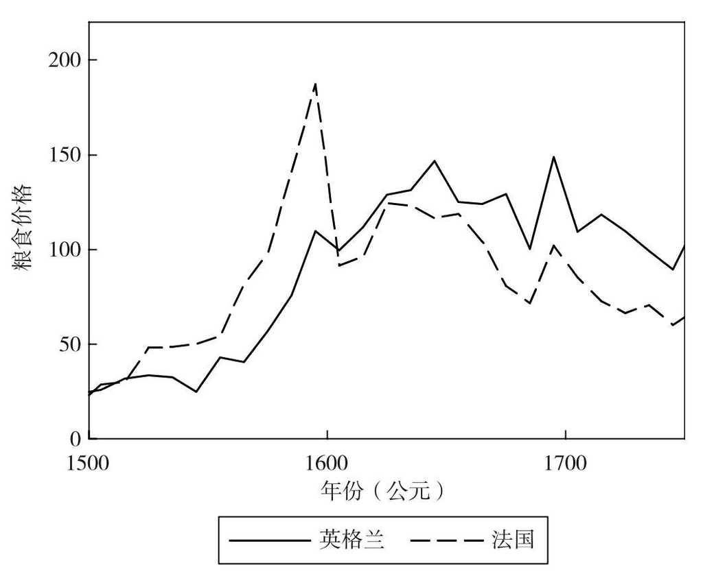

图9.3 公元1500—1750年法国和英格兰的粮食价格变动情况

资料来源：Abel（1966）。

波旁王朝的波动

法国的政治动荡期从公元1560年延续到1660年，跨度约为一个世纪。这期间出现两次国家崩溃：第一次是宗教战争达到高潮（在1590年左右）；另一次是投石党运动（在1650年左右）。前一次国家崩溃引发了瓦卢瓦王朝与波旁王朝的朝代更迭。在这两次事件中，政府都丧失了对首都的控制，被引发的内战极其血腥暴力，特别是在北部地区。

在宗教战争和投石党运动期间，政局相对稳定（除了路易十三未成年那段时期）。有学者（Dupâquier et al.，1988b，第152页）认为，当时出现了三次人口下降期，分别是1580—1597年、1626—1631年和1660—1663年。这几次人口危机极其严峻，特别是第一次和最后一次。第一次危机使人口降幅高达20%以上（Benedict，1985，第96页）。在最后一次危机中，北部和东部部分省份的居民减少了一半左右（Dupâquier et al.，1988b，第152页）。

到了17世纪60年代中期，这个多事之秋走到了尽头，又引发了新一轮领土扩张（参见图9.1）。因此，我们可以看到，法国在以下三个时期实现了强势扩张：13世纪、15世纪和1660—1710年。换言之，长周期对国家的扩张能力产生了直接影响。另外还要强调的一点是，每一波扩张期持续的时间都比前一波扩张期短，而且获得的土地也更少。这个趋势表明要么群体感在下降，要么受到后勤保障的制约（或者两者兼而有之）。

波旁王朝的周期终结于法国大革命。引发大革命的事件众所周知，而且戈德斯通已经从人口-结构理论的角度对它们进行过探讨，因此本书不会赘述这些内容。我只想强调，法国的政治动荡期从1789年延续到1848年，而且在此期间经历了大革命、波旁王朝复辟、1830年革命和1848年革命以及最终成立的法兰西第二帝国等诸多事件，之后再次进入帝国主义扩张期（尽管这次的结果并不尽如人意），不过这超越了我们为研究设定的时间下限，即公元1900年。

对同步性进行回归分析

波旁王朝的波动表现出一个很有意思的方面，即法国的动荡期会受到其他西欧国家的影响，而且影响程度随时间推移发生变化。因此，中欧的动荡期出现在1618—1648年的“三十年战争”期间。英格兰的动荡期出现在1640—1690年［如英格兰革命（English Revolution）、斯图亚特王朝复辟和光荣革命］。西班牙的危机出现在17世纪40年代，即葡萄牙加泰罗尼亚（Catalonia）的叛乱和意大利南部的叛乱（尽管我们不应该忘了荷兰在16世纪下半叶的叛乱）。似乎只有俄罗斯和法国有相同的发展轨迹（下一节会深入分析这个问题）。

我们刚才进行的简要对比引发了很多有意思的问题。首先，为什么近代早期的国家崩溃往往会波浪式出现（Goldstone，1991b）？17世纪的危机和19世纪的革命时代对欧洲、中东（奥斯曼土耳其帝国）和东亚（中国）产生了影响。其次，尽管各个政权的发展轨迹大体保持同步，但对“17世纪危机”的精细结构进行研究后发现，它们绝不会完全同步。此外，尽管俄罗斯在17世纪危机中表现出来的动态与法兰西大致保持同步，但随后两者的动态就出现了错位——20世纪初俄罗斯爆发了革命，国家崩溃，而不是像中欧和西欧那样在19世纪中叶就经历了这一切。

我们可以试着用纯粹的外生因素来解释这种现象，如气候波动（Galloway，1986；Goldstone，1991b）。因此，14世纪肆虐的瘟疫可能“重新设定”了很多政权的状况，使它们处于相同的初始条件（瘟疫本身是由蒙古超级帝国带来的）。另外一个可能性是某些“感染”引发了正向空间自相关。譬如，葡萄牙、加泰罗尼亚和西西里几乎可以同时发生起义，其原因就在于一个地区的反叛会鼓励其他地区也揭竿而起。同样，众所周知1848年欧洲的革命浪潮是由欧洲大陆其他国家传来的消息掀起的。此外，动态系统理论提出了第三种可能性。

如果两个振荡系统受到相同机制的驱动，导致它们的周期趋同一致，那么它们很可能会因为恰好在大致相同的时间同时启动，而机缘巧合地保持了同步振荡（Turchin and Hall，2003）。如果事实的确如此，那么它们之间的相位差异很可能会随着时间的推移持续存在。譬如，法国早于英格兰摆脱14世纪的危机。到了1450年，法国已经进入上升期，而英格兰还没有经历导致本国瓦解的最后一击——玫瑰战争（1455—1485年）。这使英格兰的人口-结构周期比法国推迟了半个世纪左右。因此，我们可以预期英格兰的下一个国家崩溃期应该晚于法兰西。显然这与历史走向完全吻合：1590年，一场严峻的危机全方位冲击了法国，而英格兰直至1640年才进入这个阶段。当然，此外还有一个原因或许能解释这两个国家的相位差异。人口-结构理论只预测了引发危机的压力如何逐步成形，而危机需要一个事件的触发才能真正启动，而这个事件的出现只是时间问题。譬如，农业君主国的触发事件通常是争夺王位。因此，尽管两个政权承受的压力程度相当，但它们陷入危机的时间可能会相差10年，具体相差几年取决于他们各自的君王何时驾崩。然而，以近代早期的法国和英国为例，看起来它们陷入危机之前承受的压力确实存在差异。粮食价格是一个能够充分反映财政压力的指标，而且要强调的是，法国的粮食价格上涨节点早于英国（请参见图9.3）。法国的粮食价格在1590年达到最高值（随后在1620年至1640年间再次达到峰值）。与此相对的是，英国的粮食价格顶点直至1640年才出现。因此这些数据表明法兰西和英格兰确实存在相位差异。请注意在随后出现的政治动荡中，法国再次率先进入大革命时期。反之，英格兰的政治危机直至19世纪30年代才异常尖锐（但没有导致国家崩溃。请参见Goldstone，1991b）。

前文的讨论只是想给读者带来一些启发，仅此而已。不过，很显然我们可以设计出有意义的实证检验，从三种迥然不同的原因中找出可以解释不同政权发展同步这一现象的原因（以及相位差异持续存在的现象）。此外，事实上这三种机制（即外源机制、内源机制和空间自相关机制）可能共同制造了我们观察到的同步模式（Turchin and Hall，2003）。譬如，动态系统存在着按照特定时长发生振荡的内在倾向，这或许与外力作用相互影响，使不同政权产生同步振荡。前文已经提到一种可能性，即所有系统同时受到强大的外力冲击（如黑死病）。另外一个更加不易察觉的机制是，轻微的气候变化会影响人口的承载力。数值检验的结果表明，即使承载力的相关变化极小（如变化幅度在10%~20%），也可能使受到“自私精英”模型驱动的两个政权在动态上实现同步发展。

分权阶段的精细结构

法国的发展历程还清晰地反映出另外一个很有意思的模式，即分权阶段并不总是糟糕透顶，但它有自己的规律性变化。因此，“百年战争”包含了两次异常严峻的危机（分别在1360年左右和15世纪20年代），两次危机的间隔约为50年。在危机结束后的分权阶段，法国的政治动荡再次于16世纪90年代和1650年左右分别达到最高潮。法国大革命中最严重的危机出现在1790年左右，在之后的拿破仑和波旁王朝执政期间，国内形势相当稳定。这个短暂的喘息之机结束后，1830年革命和1848年革命再次使法国陷入政治动荡期。很难说这只是个巧合，还是其中蕴含着有规模的模式。如果的确存在有规律的模式，那么可以解释这种振荡的一个原因可能是经过漫长的动荡期（如10年），人们开始渴望安稳。虽然引发危机的基本条件没有被消除，但人们仍然会默认当时重建了秩序的政治安排。因此，在动乱年代成长起来的一代人可能会不惜一切代价维护秩序，即使当时的统治政权在人们看来并不具备正当性。不过，接下来的一代人没有亲身经历过动乱，很容易受到煽动来推翻现行秩序。这种动态会产生一个跨越两代人时间的周期，即它的时长为40年至60年。此外，有些与理查德·伊斯特林（Richard Easterlin，1980）的描述非常相似的机制或许也在运行。社会政治动荡加剧，抑制了出生率，同龄人口的规模减少，随之人们之间的竞争强度下降。因此，这一代人在经济上更加富足，动员潜力较低，子女数量较多。此类机制应该会促使人口规模较小且温顺的世代与人口规模较大且好斗的世代交替出现。上文提到的两个解释原因并不是必须二择一，而是可以共同产生作用。此外，本节的讨论可能对康德拉季耶夫波动（Kondratieff wave）与战争之间的关联（Goldstein，1988）以及近年来研究全球体系的文献产生非常有意思的影响（Modelski and Thompson，1996）。

### 9.1.3 结语

如果我们数一数出现了社会政治动荡和人口下降的世纪（这些数据更容易从历史记录中找到），那么可以观察到高卢-法国依次出现了以下动态：3世纪—6世纪—9世纪—14世纪—17世纪—19世纪，即在两千年的时间里出现过六次振荡。除了一次振荡以外，另外五次振荡都持续了两三个世纪。唯一的例外是10世纪至14世纪，我在前文提到过它是一个内部周期。因此，长周期的时长完全符合人口-结构理论的预测结果。此外，尽管我们手头的定量数据不足（如李四光整理的中国定量数据），但我们追踪了这个地区的定性动态，研究结果也与理论预测保持一致。

## 9.2 俄罗斯

### 9.2.1 边境起源

欧洲的大草原边境

很多历史学家都指出大草原边境对俄罗斯的历史至关重要（Presniakov，1918；McNeill，1964；Kargalov，1974；Wieszynnski，1976；Armstrong，1982；LeDonne，1997；Khodarkovsky，2002）。1992年出版的《俄罗斯史》（Russia History）用整整一期探讨了这个问题［请参见Hellie（1992）和他随后发表的文章］。

欧亚大陆的内陆遍布着广袤的大草原。欧亚大草原从东部的大兴安岭（在中国的北部边界）向西绵延不断地一直伸展到喀尔巴阡山脉（Khingan Mountains），随后越过喀尔巴阡山脉到达匈牙利平原。在欧洲东部，草原与林地交替向东北和西南部延伸，几乎贯穿了KAZ、SRU、UKR和ZAP等文化区（请参见图5.1）。此外，欧亚大草原绕着黑海进入MOL和VLH，并且延伸进中欧（即HUN，匈牙利平原）。最后，安纳托利亚高原（ANT）也可以看作是它的延伸部分，尽管这个区域属于干草原。

至少从西米里族（Cimmerian）定居这里［即公元前1000年，请参见Riazanovsky（2000）］一直到18世纪，草原的统治者始终是游牧的牧民。农民从公元前4000年开始在林地安家落户（Riazanovsky，2000，第13页）。因此，在大草原的整个历史（和史前年代的大部分时间）里，森林和大草原之间的过渡区域一直是元民族之间的边境。然而，要注意的是大草原边境并不是固定不变的，而是会来回移动（下文会仔细讨论这个问题）。此外，草原上爆发的冲突的强度往往时盛时衰。尽管人们对于印欧语系的游牧民族占领草原时的情况知之甚少，但农民和牧民之间的文化差异应该不会太大。因此，现代俄语中的很多宗教术语都源于伊朗，表明东斯拉夫人和说伊朗语的游牧民族［如塞西亚人（Scythian）和萨尔马提亚人（Sarmatian）］拥有共同的宗教元素。从公元3世纪末开始，居住在大草原上的伊朗语族游牧民族受到一波又一波突厥人和蒙古人的进攻，最终被取而代之。这或许拉大了边境上的文化差异。不过，基督教和伊斯兰教这两个世界宗教将自己的影响延伸到东欧后，边界上的冲突强度达到极致。安定下来的农民往往会接受基督教，而游牧民族则信奉伊斯兰教。

公元前7世纪，黑海北岸落入希腊人的殖民统治后，草原边境南部的社会族群复杂性进一步加深［奥尔比亚（Olbia）、克森尼索（Chersonesus）、塔内斯河（Tanais）、潘提卡帕伊昂（Pantikapaeum）和法纳戈里亚（Phanagoria）；参见Riazanovsky（2000，第14页）］。希腊的殖民统治推动了博斯普鲁斯王国（Bosporan Kingdom）的兴起，而它最终相继落入罗马帝国和东罗马帝国手中。以上这些态势导致东欧大草原一直被紧紧夹在两条迥然不同的边境中间：南部边境处于文明帝国（此处的文明帝国指出现城市化的国家）和大草原之间（MOL、ZAP、AZV）；北部边境处于大草原与农民安居乐业的林地之间（MOL、ZAP、UKR）。元民族边境理论预测了这个地区应该是民族政体形成（ethnopolitogenesis）集中发生的场所。

这与历史事实完全吻合［Riazanovsky（2000，第13—16页）简要概述了这部分内容］。第一个强大的政权是由塞西亚人建立的。在公元前7世纪至公元前3世纪，他们一直是东欧大草原的绝对霸主，但后来被萨尔马提亚人击败并取而代之［萨尔马提亚人又被称作“阿兰人”（Alan）］。萨尔马提亚人对这片土地的统治一直延续到公元200年左右，随后臣服于哥特人。在公元200年至370年间，哥特人成为东欧大草原的主人，之后匈奴人粉墨登场——匈奴人或许是由原始突厥族人进化而来的，而且其中包括大批蒙古人和乌戈尔人（Ugrian）。匈奴入侵标志着某种分水岭，因为自那以后，所有登上大草原这个历史舞台的游牧民族都不使用印欧语系（如乌戈尔人、突厥人和蒙古人）。

匈奴攻克东哥特王朝和西哥特王朝后，东欧大草原上没有再出现过强大的政权。此后许多发源于中亚的入侵者多次穿越大草原，在大草原西边或南边建立自己的政权。昙花一现的匈奴政权的核心位于潘诺尼亚（Pannonia）（HUN地区）。到了9世纪，阿瓦尔人（他们的入侵要追溯到公元558元）和马扎尔人追随匈奴的足迹也来到这里。相反，保加尔人不断向南迫近，直至巴尔干半岛的东北部，并于7世纪在那里建立了多瑙河保加尔汗国（Danubian Bulgar）。几乎与此同时，可萨人（Khazar）在大草原东边建立了另一个游牧民族王朝——可萨汗国（Khazaria），它的核心位于伏尔加河三角洲地区。因此在公元900年以前，东欧大草原西边（如阿瓦尔人和随后的马扎尔人）、南边（如保加尔人）、东边（如可萨人）和最终北边（如9世纪建立的基辅公国）的强大政权在这片土地上纷争不断。

基辅公国的序幕

基辅公国的起源并不为人所知，时至今日仍然在史学界引发很多热议。我们可以明确的是，在9世纪前，UKR地区的主要居民是斯拉夫人——无论他们在什么时候以何种方式定居这里（学界权威仍然对此意见不一）。在森林与草原的过渡地区，斯拉夫人同化了部分伊朗人、波罗的海人（Baltic）和芬兰-乌戈尔人（Finno-Ugric）（Novoseltsev，2001）。草原上的主要居民是游牧的牧民，上文已经简要总结了他们的历史，可见他们的民族起源极其错综复杂。

从7世纪开始，东欧大草原的东部处于可萨汗国的统治下。可萨汗国是东欧历史上的第一个强权大国，对这个地区的民族形成和政体形成产生了决定性影响（Novoseltsev，2001）。可萨人或许是在6世纪和7世纪由原始突厥人、乌戈尔人和伊朗人相互融合形成的（Novoseltsev，2001）。可萨汗国的核心区域位于达吉斯坦（Daghestan）（即高加索东北部），而当时它处于萨珊王朝的北部边境。最后一个导致可萨政权被推翻的触发事件是阿拉伯人在7世纪中叶占领萨珊王朝后入侵可萨汗国。阿拉伯人在杰尔宾特（Derbent）和高加索山脉主要山坳通道建立了不少根据地，对可萨汗国施加了沉重的地缘政治压力，最终于737年一举攻占后者的都城萨曼达尔（Samandar）（Novoseltsev，2001）。在我看来属于相当典型的反流效应（请参见第4.2.2节）的影响下，可萨汗国一路向北强势扩张［请参见Farrington（2002，第83页）中的地图］。到了8世纪中叶，可萨人占领了顿河下游的克里米亚半岛和伏尔加河中下游地区。俄罗斯的编年史显示，东欧大草原在某个时间点也被它征服了，同时其他东斯拉夫群体要向可萨汗国纳贡（Novoseltsev，2001）。因此，到了9世纪，居住在UKR地区的斯拉夫人发现自己位于一个帝国的边境，与极其咄咄逼人的异族王朝两相对峙。

促使UKR地区成为民族大熔炉的最后一个因素是斯堪的纳维亚商人和盗匪——俄罗斯编年史里将他们称作“瓦兰吉人”（Varangian）。斯堪的纳维亚人以波罗的海为起点，沿着沃尔霍夫河、伏尔加河和第聂伯河等重要的商队路线建立起一个定居点网络。随着时间的推移，这个网络中的部分定居点性质发生变化，从商栈变成了当地的酋邦核心，最终发展成国家（其中最著名的定居点是诺夫哥罗德和基辅）。

在这些新生政权中，实力最强的是基辅公国（阿拉伯国家称之为“罗斯汗国”）。罗斯汗国是依靠贸易和劫掠为生的精锐部队组成的联盟。它向居住在森林以及森林-草原混合区且以务农为生的斯拉夫人、波罗的海和芬兰人索取贡品（Hosking，2001，第33页）。在这个阶段，基辅政权是一个非常典型的复杂酋邦——基辅的大公（Great Prince）是至高无上的首领，而各个东斯拉夫部落的大公属于级别次之的首领。将这个政权团结起来的凝聚力是边境“野蛮人”部落联盟擅长的防御和掠夺。

在欧洲草原边境安家落户的务农者常常被迫应对游牧民族的烧杀劫掠。如上文所述，在8世纪和9世纪，很多东斯拉夫部落必须向可萨汗国进献贡品。然而到了900年以后，佩切涅格人（Pechenegs，又称Patzinaks）从可萨汗国的势力范围突围而出（Novoseltsev，2001），在东欧大草原上站稳脚跟，大大提升了东斯拉夫受到侵袭的压力（Hosking，2001，第34页）。正如我在前文指出的那样，在之前的五个世纪里，这个区域（ZAP和AZV）没有孕育出任何大型游牧政权。或许基辅公国与佩切涅格联盟基本在同一时间初具规模并不完全是出于巧合。帮助佩切涅格崛起的潜在机制或许与巴菲尔德（1989）描述的中国农业社会与中亚游牧王朝的互动机制比较类似，本书第7.2.3节对巴菲尔德描述的这个机制建立了模型。下文简要描述了我们假设的动态。以基辅为根据地的瓦兰吉人利用自己的军事优势强迫周围的斯拉夫部落向它进贡，或许还可以为他们提供更好的保护，使他们免受草原上与其势不两立的掠夺者攻击。此时草原的居住者必须提高自身的军队规模才能攻克农民不断加固的防御工事。此外，日常用品和贵重物品不断向基辅汇集，最终还集中到其他城镇，越来越强烈地激励基辅政权不断扩大自己在草原上的政治组织。因此，来自草原的压力陡然上升，使农民受到更多激励实行中央集权，正反馈回路促使农业政权和游牧政权都加强中央集权，直至受到生态和后勤条件的约束。

共同防御并不是唯一促使基辅罗斯提高群体感的力量。作为这个政权的精英战士，瓦兰吉人本身就是臭名昭著的掠夺者。他们最觊觎的是富足的君士坦丁堡，他们的袭击目标就是拜占庭帝国，如他们发动了奥列格（Oleg）战役和伊戈尔（Igor）战役。此外，在斯维亚托斯拉夫大公（Prince Sviatoslav）执政期间（即10世纪下半叶），基辅罗斯洗劫了伏尔加保加尔汗国的都城，给了可萨汗国沉重的一击。此外，它还攻占了多瑙河保加尔汗国的都城。基辅公国的精英战士需要获得大批武装力量来攻占这些实力强劲的政权，同时取得成功后又会使他们声名大震，这或许是促使他们极其团结一心的原因。

我们可以推测一下为什么基辅公国在UKR地区成功地整合成一个国家（state）（而不是在SRU或ZAP地区）。这一研究会很有意思。史书强调了贸易的重要性［如Kliuchevskii（1911）强调了水路的重要性］，而这个假设得到当今人类学理论的支持，这个理论强调了贵重货物在酋邦进化过程中的重要性（Earle，1997）。在第一个千年的下半叶，东欧拥有两条重要的贸易通道：一条借道第聂伯河，另一条借道伏尔加河。有意思的是，我们要注意第聂伯河和伏尔加河上的贸易通道与森林-草原过渡区域交汇的地点几乎同时成为政治动态极其激烈的中心（即UKR的基辅和KAZ的大保加尔城）。同样，随后崛起的贸易主干道是多瑙河，而这里正是多瑙河保加尔汗国建立王朝基业的地方。

在东欧的元民族发展过程中，有一个重要事件是世界宗教在第一个千年行将结束时降临这片土地。第一个世界宗教是犹太教，被可萨汗国奉为国教。然而，10世纪可萨汗国覆灭之后，犹太教对这个区域的影响非常有限。伏尔加保加尔汗国信奉了伊斯兰教，而且成功地在13世纪和14世纪使蒙古人也皈依这个教派。最终东欧的所有游牧民族都成为伊斯兰教信徒（后期信奉佛教的蒙古人入侵这里的情况除外）。与之相对的是，斯拉夫和其他农耕民族皈依了东正教。因此，在第二个千年初期，宗教边境出现的同时，恰好也出现了将农民与牧民分隔开的经济边境。这种态势导致贯穿整个东欧的元民族断层线大幅加深。

俄罗斯的民族形成

俄罗斯的民族“起源地”位于罗斯东北部［该地区又被称为“弗拉基米尔-苏兹达尔罗斯”（Vladimir-Suzdal Rus）］。我必须立即声明，这里所说的“起源地”并不是指某个划定的具体区域。因此，莫斯科本身、伏尔加河-奥卡河在美索不达米亚的流域、罗斯东北部、前基辅公国的其他领土以及东边的金帐汗国，都对俄罗斯的民族形成做出了贡献，只是程度各异，通常来说，他们与莫斯科的距离越远，做出的贡献就越小。

弗拉基米尔-苏兹达尔罗斯位于罗斯的东北边界（请注意我用“罗斯”指代蒙古入侵前的时期，用“俄罗斯”指代蒙古入侵后的时期。这是因为由于罗斯和俄罗斯的核心区域截然不同，所以“罗斯东北部”相当于“俄罗斯中部”）。在蒙古入侵俄罗斯前夕，这里的居民混合了来自波罗的海、芬兰和斯拉夫的各种部落。部分俄罗斯史学家（如Kliuchevskii，1911）认为罗斯东北部之所以有人居住，是因为斯拉夫人到处大肆占领殖民地。其他人（Paszkievicz，1983）则认为“大俄罗斯人”只是被斯拉夫化的美力雅人（Merya）（美力雅人是一个芬兰部落，居住于伏尔加河-奥卡河在美索不达米亚平原的流域）。无论具体情况如何，显然在第二个千年的头几个世纪里，罗斯东北部的居民日益被斯拉夫语系和东正教同化。与此同时，它还受制于欧洲历史上局势最紧张且持续时间最长的一条元民族边境。

到了11世纪，基辅罗斯的东北边境风平浪静。这条边境位于使用斯拉夫语的基督教徒和以芬兰语为主的异教徒之间。此外，基辅罗斯的城市文化日益兴盛。随着人口密度不断提升，他们的农业生产的集约程度超出了原住民的实践。另一方面，斯拉夫人被基督教化可能是一个渐进过程（请参见第6章），与此同时，越来越多非斯拉夫人也开始皈依基督教。

在12世纪和13世纪（特别是后者），草原上的边境不断向北推进，造成这种现象的部分原因在于基辅政权内部出现权力分化（请见下文了解详情），部分原因在于新的游牧部落从中亚迁移到这里：首先是11世纪中期的库曼人（Cuman）（俄罗斯将他们称为“钦察人”），其次是200年后的蒙古人。在12世纪，基辅的国家中心既是留里克人（Ryurikid）的各个派系同室操戈的地方，也是库曼人不断加大突袭力度的目标。随着人口密度下降，众多定居地被废弃，四处游牧的掠夺者必须向北压进才能获得战利品和奴隶。在13世纪，库曼汗国和东斯拉夫的众多公国完败于蒙古人的铁蹄之下。尽管罗斯的东北部成了金帐汗国的属地，但并没有让来自草原的压力消失。首先，蒙古人没有直接统治俄罗斯，而是依靠当地财权获得贡品。这种关系需要蒙古人定期对俄罗斯进行具有惩戒性的讨伐，以提醒当地精英和民众如果不进贡就要纳税。在13世纪晚期和14世纪，俄罗斯的许多城市多次爆发反抗蒙古人的起义。人们尤为不满的是，未能按照官府要求上缴贡品的家庭要沦为奴隶（Hosking，2001，第55页）。其次，从来没有一位草原统治者可以完全掌控自己的追随者，而且他们也在采取一定的劫掠行为，14世纪中期金帐汗国的中央政权开始式微后，草原的劫掠行为不断恶化。

到了15世纪中期，金帐汗国最终消亡。在之前隶属于金帐汗国的领土外围出现了三个强大的政权：莫斯科公国（Principality of Moscow）、喀山汗国（Khanate of Kazan）和克里米亚汗国。俄罗斯的领土频繁遭到喀山鞑靼人和克里米亚鞑靼人的残酷劫掠，承受着巨大的压力。游牧民族掠夺者的主要动机是为了获得奴隶。有些学者对此估算后认为，在17世纪上半叶，有15万至20万俄罗斯人被他们掳走充当奴隶（Khodarkovsky，2002，第22页）。

我将13世纪至16世纪CRU元民族边境上的冲突强度定为9，这是可能出现的最高值。基督教和伊斯兰教之间的宗教分裂强度定为3，语系差异的强度定为2，经济生活方式的强度定为2，战争的强度定为2。最后一个指数从本质上反映了草原边境在这一时期呈现出种族灭绝的特点。由于外族劫掠导致居民死亡或被奴役，森林-草原的过渡区域有一大片地带人口减少，幸存者纷纷迁往防御能力更强的地区。因此，务农者彻底放弃了之前的基辅公国核心地区。梁赞公国（Principality of Ryazan）的大部分领土已经被遗弃，包括它的旧都（它的新都被迫迁往西北部的佩列亚斯拉夫-梁赞）。剩下的人则不畏艰险地坚持居住在梁赞公国的西北角。

草原北边的局势截然不同。在13世纪，波罗的海地区的东部成为拉丁基督教世界推进十字军东征的前沿之一（Shaskolsky，1978；Bartlett，1993；Murray，2001）。丹麦人侵占了爱沙尼亚（Estonia）。德国的十字军骑士入侵了立沃尼亚（Livonia）。瑞典占领了芬兰南部。这些以日耳曼语为母语的天主教信徒开始对俄罗斯西北部的城市共和国施以重压，如普斯科夫和诺夫哥罗德。我认为，我们至少可以出于以下两个原因，将波罗的海边境认定为一条重要的元民族断层线。

第一个原因涉及意识形态，拉丁基督教宣称十字军东征的目的是反对它的敌人：异教徒和“分立教会者”。这个举动表明，到了13世纪40年代，东正教和天主教这两个基督教分支之间存在巨大的分歧，可以分别被视为一个元族群。有意思的是，俄罗斯正是在13世纪出现了元民族地名Nemsty（Lind，2001）。Nemsty指代西欧的所有非斯拉夫人。在13世纪，过去指代丹麦人和瑞典人的民族术语（Don’和Svei）从俄语中彻底消失了。后来人们需要对Nemsty在公元1500年前后出现的诸多同种同文化民族进行区分，不得不创造出新的术语（即Datchane和Shvedy），同时将Nemsty保留下来指代所有日耳曼人。

第二个原因是冲突的强度，东正教和天主教之间的冲突极其激烈，不时会导致民族灭绝（ethnocidal），甚至种族灭绝。波罗的海十字军对普鲁士等原住民造成的影响众所周知。一直到16世纪的立沃尼亚战争，边境上的争斗仍然异常激烈，导致整个立沃尼亚地区的人口急剧减少。

简而言之，基辅罗斯瓦解之后，它的北部边境成了各方武装势力的“竞技场”，夹在两条元民族边境之间被反复碾压。冲突强度最高的元民族断层线是由草原边境北移造成的。草原产生的压力导致UKR和SRU地区人口减少，同时CRU和KAZ地区在15世纪出现了多个权力中心（即特维尔、莫斯科和喀山）。第二条元民族边境位于草原西北部，冲突强度略微低一些（我将其强度定为6）。莫斯科公国在15世纪末攻占诺夫哥罗德（和特维尔）后，同时受到这两条边境的影响。在那之后，俄罗斯的历史基本上就是这些边境从伏尔加河-奥加河心脏地带逐步外移的历史。至少在18世纪以前，俄罗斯始终是一个边境国家，一直到18世纪末它攻占了克里米亚汗国后，草原边境消失。在同一时期，俄罗斯还吞并了波兰和芬兰，进入欧洲列强体系，随之改变了波罗的海边境的特性。不过这些情况出现在我们所研究的时间段行将结束之时，所以本书不会在这里继续深入探讨它们。

### 9.2.2 长期波动

基辅的波动

雅罗斯拉夫一世（Iaroslav the Wise）的统治期（1019—1054年）是基辅公国的历史上最强盛的时期之一。他的继任者上台后，基辅罗斯进入漫长的衰落期，精英阶层内部的竞争愈演愈烈，最终整个国家分崩离析。雅罗斯拉夫一世去世后的170年里爆发了80场内战（Pogodin，转引自Riazanovsky 2000）。不过在长周期的分权阶段，内部冲突极为激烈的两个时期之间会穿插一个相对稳定的时期（我们已经在法国的案例分析中注意到这个模式）。基辅的稳定期出现在弗拉基米尔·莫诺马赫大公和他的两个儿子执政时期（即1113—1139年）。第二个内战期出现在12世纪中期，导致基辅公国最终灰飞烟灭。1169年，安德烈·波戈流比斯基（Andrei Bogoliubsky）洗劫了基辅，将都城迁至罗斯东北部的弗拉基米尔。1203年，基辅再遭劫掠，并于1240年被蒙古人彻底摧毁（Riazanovsky，2000）。

金帐汗国的内部周期

到了1200年，基辅公国的核心已经彻底瓦解。基辅罗斯的南半部成为留里克人的三个分支相互争斗的战场，即斯摩棱斯克（Smolensk）的罗斯季斯拉维奇（Rostislavichi）、切尔尼戈夫（Chernigov）地区的奥尔加维奇和沃里尼亚（Volynia）的罗曼·姆斯季斯拉维奇（Roman Mstislavich）（Fennell，1983）。诺夫哥罗德和弗拉基米尔这两个相对稳定的政权在北方傲然独立。已解体的国家的核心周围环绕着正在崛起且四处征战的国家（marcher state），这个空间模式是后帝国时代的典型特点（请参见第4章）。然而，基辅罗斯的内生演变过程被来自中亚的侵略者强行中断了。在大约200年的时间里（从13世纪中期到15世纪中期），罗斯（特别是它的东北部）成了蒙古帝国的外围（或者说，蒙古帝国被成吉思汗的后裔瓜分后，罗斯成了金帐汗国的外围）。这种地位的转变导致罗斯东北部［或俄罗斯中部（CRU）］的政治动态是由外力决定的，而这些外力来源于帝国草原联盟，下文将一直使用“俄罗斯中部”这个概念。因此，我将这200年称作“内部周期”。然而，需要强调的是，最近谢尔盖·涅费多夫（2002b）提出了一个令人信服的观点，即蒙古时期本身可以被看作一个完整的长周期，特别是在蒙古的影响力较弱的诺夫哥罗德地区。

第7章的人口-结构模型表明，农业国家的精英阶层采取一夫一妻制时，这种国家的周期往往要比精英阶层采取一夫多妻制的游牧联盟周期更长。由于俄罗斯中部成为草原政权的外围，所以对它产生影响的“历史节奏”与蒙古统治时期之前或之后的典型节奏截然不同。下文列出了格鲁塞（Grousset，1970）的研究结果。他总结了欧亚草原和其周边地区发生的一系列事件。

在13世纪上半叶，蒙古占领的广袤领土包含四个大“文化区”且这些地区都有定居人口，即中国、河间地带、波斯（包括美索不达米亚）和东欧。从13世纪中期开始，这四个区域分别被元朝的四个世家统治着，即（1）统治中国的忽必烈和他的继位者（即元代）；（2）统治土耳其斯坦的察合台（其中包括河间地带）；（3）统治波斯的旭烈兀和他的继位者（伊利汗）和（4）统治钦察草原（即金帐汗国）的Juchids（拔都和他的继位者）。根据第7章提出的理论，这四个政权应该符合伊本·赫勒敦周期的特征，而且持续了一个世纪左右。事实也确实如此。

在中国，1328年忽必烈的继承者之间爆发了内战。在14世纪50年代，中国本土的原住民多次发动起义。1368年，其中一支起义军赶走蒙古人，建立了明朝。

土耳其斯坦在1333年至1334年之前实现了统一。当时土耳其斯坦本地的游牧民族带领人们起义反对察合台。到了1350年，河间地带的统治者变成当地的突厥贵族。经过一段时间的战乱纷争后，帖木儿建立了新的王朝并在1379年统一了河间地带，随后在14世纪90年代占领伊朗。帖木儿王朝也持续了约一个世纪。1469年，波斯落入白羊王朝（White Sheep Horde）手中，河间地带被帖木儿后裔的分支瓜分，而且这些部落之间一直争斗不断。

旭烈兀的波斯王朝在1335年解体后一直处于战火中，直至被帖木儿占领（请参见上文）。1469年，帖木儿汗国失去对波斯的掌控后，时局再次动荡不安。最终波斯于1500年建立了原住民执掌的王朝（即萨非王朝），重新实现统一。

这一系列事件也发生在钦察草原上。Juchids的统治于1359年走到尽头，钦察草原陷入无政府状态。经过一段时间的内战纷争后，金帐汗国在帖木儿·忽格鲁特的统治下再次振兴，于1391年（在帖木儿的帮助下）赶走金帐汗国的大汗脱脱迷失（Tokhtamysh）。1399年，帖木儿·忽格鲁特与立陶宛人对决时取得重大胜利，将俄罗斯纳入它的领土版图，尽管在15世纪初，他需要发动一系列具有惩戒性质的远征来确保俄罗斯持续向他纳贡。不过到了15世纪中期，中兴后的金帐汗国再次开始瓦解。当时第一个脱离金帐汗国并独立建国的国家是1430年成立的克里木汗国（Crimean Khanate）。喀山汗国和阿斯特拉罕汗国追随其后，于1445年和1466年相继成立。

莫斯科政权在15世纪的第二个25年里经历了自己的内战期。令人好奇的是，这个内战期与导致金帐汗国最终四分五裂的内战期基本重合。内战结束后，莫斯科公国实际上成为一个独立的国家（它直至1480年才实现法律认可的独立）。

总之，蒙元帝国的所有朝代都经历了典型的伊本·赫勒敦周期，而且这些周期持续一个世纪左右。在中国，本土人民经历了一个周期后将蒙古人赶出家园，建立起自己的王朝，而在俄罗斯和伊朗，草原王朝经历了两个周期后才让位于本土的统治者。附带提一句，欧亚中部的大草原仍然处于伊本·赫勒敦周期，直至它们被俄罗斯和历代中华帝国攻占并瓜分。

莫斯科公国的波动

然而，到了16世纪70年代，莫斯科公国的扩张开始显露疲态。漫长的立沃尼亚战争（1558—1583年）实际上导致莫斯科公国的土地在流失。史学家提供了很多原因来解释波兰-立沃尼亚和瑞典为何能战胜莫斯科公国，不过我认为根本原因是长期趋势发生了逆转。

事实上，有证据支持我们用人口-结构理论来解读莫斯科公国在16世纪经历的危机——这场危机在“混乱时代”（Time of Troubles，1598—1613年）达到了最高潮（Dunning，1998）。莫斯科公国的人口规模在16世纪迅速扩大，或许翻了一番。这些人口增长多半发生在16世纪上半叶。贵族（即世袭贵族杜马）和级别略低的公职贵族的规模扩张速度超过了平民的扩张速度。粮食的价格上升了四五倍，而很多俄罗斯人的税赋增长了7倍（这是根据通胀调整后的结果）。在16世纪70年代，莫斯科公国的经济下滑至岌岌可危的境地，大批农民和城市纳税人被迫逃离家园。在莫斯科公国的中心区域和西北边陲（即诺夫哥罗德地区，它也在立沃尼亚战争中深受其害），人口持续减少，由此造成的后果是税收损失惨重。无论国家还是公职贵族的收入都锐减（Dunning，1998）。

政治动荡对莫斯科公国造成了两波影响。政治动荡加剧的第一个时期是1565年至1572年的特辖区时代（Oprichnina）（Riazanovsky，2000，第149—151页）。这个时期的特殊之处在于它是君主本人发动的政变，利用一部分精英（即特辖军）压制其他精英。费奥多尔一世在位期间（1584—1598年）相对说几乎没有爆发内战，是动荡年代中的一个小插曲。在此期间，莫斯科公国大胜瑞典，收回了之前在1583年签署的休战协定中割让给瑞典的领土（Riazanovsky，2000）。然而，费奥多尔一世去世时没有合法继承人，莫斯科公国因此进入第二个动荡时期，即“混乱时代”。在此期间，先后有四位沙皇走马灯似地迅速走上历史舞台再迅速谢幕，即鲍里斯·戈都诺夫（Boris Godunov）、费奥多尔·戈都诺夫（Fedor Godunov）、伪迪米特里一世（False Dmitry）和瓦西里·舒伊斯基（Vasily Shuisky），接踵而至的是1610—1613年的空位期。在这个时期，持不同政见的精英、来自波兰和瑞典的外国势力和克里米亚鞑靼人先后发动了多次平民起义。简而言之，这是一个完全符合人口-结构理论的典型的国家崩溃案例。要注意的是，这两个动荡时期的巅峰（即1570年和1610年）之间隔了40年，几乎相当于两代人的时间。

罗曼诺夫王朝的波动

1613年，米哈伊尔·罗曼诺夫（Michael Romanov）戴上沙皇的王冠，开启了罗曼诺夫王朝长达300年的统治。然而，俄罗斯的动荡期并没有就此结束。尽管它没有全盘崩溃，但在米哈伊尔及其继承者执政期间，它的财政状况始终岌岌可危。此外，它还花了不少时间来重建社会稳定。事实上，一直到彼得大帝执政初期，各种暴动和起义还此起彼伏地频频爆发。

然而，从17世纪中期开始，俄罗斯逐渐出现中央集权的趋势，并且相应地开始扩张领土。它首先向波兰下手，于1667年迫使波兰将乌克兰割让给自己，随之进入历史上众所周知最漫长也最成功的领土扩张期。到了18世纪，俄罗斯要么将17世纪与之势不两立的对手从列强的宝座上拉下来（如瑞典和土耳其），要么直接占领它们（如克里米亚鞑靼和波兰）。俄罗斯成为列强后，曾在1815年至1850年间短暂地称霸欧洲，甚至整个欧亚大陆。当然，它能够掌握霸权不仅是因为俄罗斯帝国具有强大的内在实力（请允许我使用一个诗歌式的比喻来描述这个情况：俄罗斯挥动波罗的海十字军造就的重锤，以草原边境为铁砧锻造出强大帝国）。俄罗斯帝国之所以能够雄霸欧洲及欧亚大陆，另外一个主要原因是它持续扩张的时间长得异乎寻常，没有与其他欧亚帝国的长周期保持一致。请注意“17世纪的危机”席卷了整个欧亚大陆，对西欧、俄罗斯、奥斯曼帝国和中国都造成影响（尽管波斯和印度不在受影响的国家之列）。在19世纪上半叶，中国和奥斯曼帝国恰好都处于自己的分权阶段（事实证明这是奥斯曼帝国的最后一个阶段）。更重要的是，西欧正处于其“革命时代”（1789—1848年），使俄罗斯得以扮演“欧洲宪兵”的角色（即镇压1849年的匈牙利革命）。英格兰虽然避免国家全盘崩溃，但在19世纪30年代，它仍然处于剧烈的社会政治动荡中（Goldstone，1991b）。因此，我们可以用俄罗斯帝国的相对实力这个因素来解释它为何能在19世纪上半叶具备压倒性的地缘优势。

我认为有两个原因可以解释俄罗斯在1650年至1850年的强势扩张。首先，俄罗斯发家于局势极其紧张的元民族边境。根据人口-结构理论，这会使它具有极强的凝聚力。其次，在俄罗斯的扩张初期，它攫取了大量人口稀少但极其肥沃的“黑土地”。这些土地被殖民化后，生活在这里的农民从1600年的1000万人增长到1900年的1亿人以上。从事生产的社会阶层大幅扩张，可以为所有精英找到就业机会。由于俄罗斯严格执行一夫一妻制，所以精英阶层的扩张速度不及平民阶层的增长速度。贵族在俄罗斯帝国的人口中只占到1%~2%（Mironov，2000），大幅降低了精英阶层内部相互竞争的可能性。

然而，任何增长都不会无限持续。在19世纪，俄罗斯帝国在欧洲领土上的人口增长了两倍，从3600万飙升至1亿（McEvedy and Jones，1978）。农民/土地比下降，粮食价格上涨，而且粮食短缺变得极其普遍。尽管贵族的人数始终保持在全国人口的2%，但一心向上爬的新型精英的规模不断扩大（如中下层知识分子）。因此，到了19世纪下半叶，俄罗斯帝国之前的“迅猛”增长逐渐回到人口-结构机制的框架内。

到了19世纪中期，长期趋势出现逆转，再加上后勤条件方面的约束，俄罗斯帝国的地缘政治发展前景被蒙上一层阴影。它在克里米亚战争中的失利只是暂时受挫，但它在其他列强的压力下被迫签订《圣斯特法诺条约》（Treaty of San Stefano，1878年），未能最终占领奥斯曼帝国，因此严重遏制了它的扩张。以下动态导致俄罗斯的地缘政治力量发生相对变化。首先，俄罗斯开始进入分权阶段。其次，其他列强国内的分权阶段刚刚结束，进入帝国主义扩张期。因此，俄罗斯只能在其他欧洲列强无法触及的地区才能继续扩张，如中亚。我们可以用日俄战争清晰地阐明帝国的内部结构变得疲弱时，会对其地缘政治扩张产生什么影响。即使俄罗斯在后勤运输上处于极其不利的位置，而且其远征海军力量在马岛（Tsushima）一役中几乎全部覆灭，但它仍然成功地聚焦起足够的军队，势如破竹般攻进满洲里（Manchuria）。不过，1905年至1907年的革命迫使政府放弃了从陆地进攻日本的计划，因为它需要加大国内的军事力量来镇压起义。

在罗曼诺夫王朝统治期间，政治动荡结束后出现了我们已经非常熟悉的两代人模式（即俄罗斯案例中的“父与子”模式）（此处借用了屠格涅夫名著的名称，特此向他致歉）。俄国的第一个动荡期出现在亚历山大二世执政期间。革命者在19世纪60年代和70年代组织了多起农民起义和恐怖活动，最终以1881年沙皇被暗杀而告终。随后亚历山大三世的执政期与之前形成了对比，国内形势相对稳定。第二个不稳定期在1905—1907年和1917年达到高潮，尽管战争引发的地缘政治压力对它产生了强烈的推波助澜作用，特别是第一次世界大战和1917年大革命。

### 9.2.3 结语

尽管俄罗斯和法国是两个迥然不同的国家，它们有自己特有的地理位置和文化，但我们从元民族边境和人口-结构理论的角度审视它们的历史时，可以发现它们有很多共同之处。首先，这两个地区都经历了两次民族演化事件，即法兰克人演化至法兰西人；罗斯人演化至俄罗斯人。这四个民族都发源于元民族边境，而且它们创造出的国家都经历过长周期。法兰克帝国和法兰西之间以及基辅罗斯和俄罗斯之间还分别存在着内周期。最终，它们的长周期的分权阶段几乎都表现出一个特点，即具备“父与子”的精细结构。在这个结构中，社会政治动荡波段式出现，且间隔为两代人的时间。

# 第10章 结语

## 10.1 主要事态发展综述

我在第1章列出了研究历史动态的大纲，其中推荐的研究方法有以下主要特点：（1）将文字理论转变为数学模型；（2）从两个或两个以上可供选择的理论/模型推导定性预测；（3）进行实证检验以确定相互矛盾的理论中，哪个理论的预测结果与实证数据契合程度最高。这一通用型研究方法（general approach）在自然科学研究中成效显著，但是否适用于解答社会问题和历史问题？我深信它是适用的，而且试图表明坚持使用这一研究方法能够帮助我们在理解农业政权的领土动态方面取得重大进展。

### 10.1.1 群体感和元民族边境

或许我在本书中讨论的最有创新意义的一项研究进展是群体感理论。所谓群体感指一个群体采取集体行动的能力（参见第3章）。我由此提出一个假设，即元民族边境的凝聚力会提高，而大型政权核心区域的群体感会下降。我用一个简单的分析模型和一个更复杂的空间模拟研究检验了这个假说，并确定了在什么条件下会观察到周而复始的王朝崛起-消亡循环（参见第4章）。随后我构建了一个实证框架来检验这个理论。事实证明这项研究任务极其重要（而且进展喜人），不过我们可以预期到，在提出新概念并且将原始实证事实转变成标准化数据时，必然会遇到重重困难（Rozov，2000，第25页）。我用这个研究框架分析了第一个和第二个千年的欧洲历史时（参见第5章），发现这个理论的预测结果得到了数据的证实。理论和数据之间的匹配程度并不完美，但完全在意料之中，因为所有科学理论至多是对现实情况的近似描述。此外，另外一个以边疆地区地缘政治优势为基础建立的理论，在预测大型政权（即“帝国”）的发源地时表现更加不尽如人意。事实上，它“猜”对的概率与我们的预期差不多。

本书中的研究首先用文字构建理论，然后对它进行全面的实证检验。我认为研究结果表明通用型研究方法可以应用于历史研究，并得出极其重要的见解。要强调的是，这项研究的价值并不在于它是验证元民族边境理论，还是最终推翻这个理论，反证了其他理论更完善。重点在于，本书中提出的这一理论顺利通过检验后，确立了一个需要被完善的标准，因此要想推翻这一理论并证实其他理论更完善，人们必然要进一步深入研究。无论最终用什么理论来解释历史动态，元民族边境（即“文明断层线”）以及随后强大的帝国从这些地区强势崛起扩张，这两者之间存在的关联都令人注目。

正如我在本书反复强调的那样，基督教和伊斯兰教等排他性宗教在很多元民族边境发挥了关键作用。然而，我的理论将特定地点出现世界宗教的情况视为一个外生事件。正如一位匿名评论者阅读本书草稿时指出：“有一个理论问题悬而未决：具备何种条件时会出现世界宗教？相对于当前的地缘政治结构，它们会传播到哪些区域？”这是一个非常好的问题。我希望自己能够解答它。然而，对于“我们如何内生化世界宗教的传播”这个问题，我目前还无法提出任何可信的假说，必须通过今后的研究来寻找答案。

### 10.1.2 民族同化

我继续对其他两个理论采用了同样的研究方法。第一个理论是宗教同化和语言同化动力学（我将它戏称为“民族动力学”）。它的文字构建工作已经大体成形，相对来说还未实现数学化。因此，我不得不从基础开始，先考虑哪种基本增长模式能够为民族同化理论的建模工作提供一个合理起点。我们利用三个案例研究进行了实证检验（即皈依伊斯兰教、基督教崛起和摩门教的发展），结果全部表明，自动催化模型的效果比非互动模型和临界模型更突出。附带说一句，在一个案例研究中，我们将自动催化模型与宗教皈依比重的时间轨迹进行拟合，得到的结果非常突出（R<sup>2</sup>=0.9998）。这不是由过度拟合造成的，因为这个模型极其简单，只包括两个自由参数，而且它的数据库以成千上万份档案为基础，规模极其庞大。换言之，高精确度并不只限于物理应用。但是，我要再次强调上一节提出的观点：重要的并不是R<sup>2</sup>的绝对值，而是我们构建出更完善的理论的过程。事实上，皈依伊斯兰教的例子很好地阐明了这个观点，因为对我们观察到的模式进行更加详尽的研究后，可以找到证据表明模型的预测和数据之间存在系统性偏差，这样我们就可以提出另外一个模型来解释这个模式（同时无须增加其他参数）。

尽管这个开端非常鼓舞人心，但是对民族动力学的研究刚刚起步。这里面有两个问题至关重要。首先，如何描述政权内社会空间的特点：即人口密度与网络缺口之间的联系（幸运的是，目前社会网络似乎成了一个颇受关注的社会学研究主题，希望能给我们带来裨益）。这一点至关重要，因为民族同化的扩散可以被网络缺口阻断。缺口的两侧甚至可能建立两个不同的稳定国家——就像伊朗出现的情况一样。伊朗的一些少数民族从来没有皈依过伊斯兰教，而是坚守拜火教（Zoroastrian）。其次，对相对同化率r等系数的定量估算。伊朗的r估算值比西班牙的r估算值几乎高出一倍（请参见表6.1）。为什么伊朗人的皈依率是西班牙皈依率的两倍？此外，有些案例表明同化的过程会发生逆转（如在18世纪，哈布斯堡王朝统治下的捷克人被德国化，但到了19世纪末，他们开始努力去德国化）。简而言之，我们需要一个理论来预测相关系数的数值。

### 10.1.3 人口-结构理论

人口-结构理论是我从文字构建入手一直到完成实证检验的最后一个理论（参见第7章）。戈德斯通等学者已经将这个理论发展得比较完善，并对它进行了检验。这很大程度上简化了我的研究工作。然而，戈德斯通提出的人口-结构理论将人口动态作为外生变量，而我希望探索的假说是：事实上人口动态与国家崩溃的动态息息相关。我做出的一个假说是政治动荡对人口增长产生负面影响，并且在将这个假说转化为模型后发现，它预测农业政权会表现出不太规律的周期，持续的时长约为两三个世纪。（在这个简单模型里）由于从国家崩溃到下一个人口-结构周期启动之间的时长并不固定，所以产生了不规律。

我们根据现有的描述人口动态的长期数据进行了实证研究，结果表明持续两三个世纪的振荡是人口动态中普遍存在的规律，而不是例外情况（参见第8章）。此外，我以朱敬一和罗纳德·李的研究为基础分析了一个数据库——这个数据库估算了公元前200年至公元1710年中国的人口动态和政治动荡。这一分析的结果有力地地表明人口和政治动荡存在内生关联。其他定性研究的结果也支撑了这个观点，其中费希尔的研究针对整个西欧，而我的研究更多地关注了法国和俄罗斯，谢尔盖·涅费多夫最近的研究结果也进一步支持了这个理论）。

这个理论还预测游牧帝国联盟的周期较短，持续的时间约为一个世纪。尽管游牧政权不是本书的研究重点，但我仍然留出些许篇章探究了后成吉思汗时代的中亚史（参见第9.2.2节），为游牧政权的动态描述提供了一些实证证据。

### 10.1.4 地缘政治

我无法全面进行实证检验的理论是地缘政治理论（参见第2章）。然而，即使只是将文字表述的理论转化成数学模型，依然有可能取得不少进展。譬如，我发现柯林斯提出的理论假设了一个机制，而且它曾经引发一阶动态（这个机制涉及地缘政治资源、后勤负载和边疆地区优势）。换言之，这个理论不能解释为什么历史上的很多帝国经历了漫长的衰落期。但纯理论研究进展展示了数学模型相较于文字描述的优势。用文字描述问题时，一些看起来合理的内容不一定能得出我们以形式化方式分析动态系统时得出的动态结果。要想找到对历史（和物理及生物）系统产生影响的非线性特征和滞后，需要专门构建一个数学模型将假设和预测连接起来。

我在实证层面应用地缘政治理论的一项研究是，检验了一个地区的位置优势会对诞生于该地区的政权的最大规模产生何种影响，但这个理论用于实证研究的效果很有限。我发现这两个变量之间不存在任何具有统计意义的联系，说明位于边疆地区并不会使政权占据明确的地缘政治优势。然而，这并不是说边疆地区诞生的政权不会凭借其地理位置暂时具备一定优势。事实上，有很多例子强有力地证明了在两条边境同时开战的国家会以失败告终，如德国在两次世界大战中的处境。不过，这个观点仍然有待严格的检验。我们需要超越轶事研究法：毕竟普鲁士在“七年战争”中也是在多处边境作战，但仍然大胜而归。地缘政治理论在实证层面的发展是另外一个需要深入研究的领域。其中我们最希望看到的研究是在指定的时期内，探讨特定地区内所有军事互动的客观性检验，因为这项检验能够规避所有有意或无意选择案例的行为。不过，收集整理一系列案例是沿着这个方向开展研究时迈出的第一步，就像我在第9章建议的那样，整理16世纪意大利在法国和西班牙之间苦苦挣扎的案例有助于推动此类研究。

## 10.2 将各种机制整合成一个综合机制

尽管我们可以认为所有理论各自取得了突飞猛进的进展（或许地缘政治理论并不在此列），但我们并不清楚如何找到一个方法将这些理论融为一体。不过，我们追踪了各种机制如何在具体政权的内部相互作用（请参见第9章），研究结果给出了一些假说，可以在今后的研究工作中进一步深入探讨。我在此介绍了自己目前对这个问题的想法（需要提醒的是，这里只是提出了假说。一旦出现新的模型和数据，以下的分析很可能会随之发生变化。）。

动态系统法中最有价值的内容之一就是它迫使我们认真关注某个机制运作的时标。本书第8.2节对各种时标做了初步讨论。我可以根据那一节之后的实证研究进一步完善关于时标的探讨。与历史动态息息相关的一个“自然”时标是一代人的时间（约为20~30年）。在这个时标上，人口规模起起落落，政治精英繁衍后代，文化四处传播且不断修正。“年份”是比它短了不少的时标，它见证了很多“生态”机制的运行，如农业生产周期和疾病暴发周期等。群体感、民族动力学和人口结构等机制运行的时标远远超过年，甚至跨越数代人。长期波动的时长最为清晰：（农业帝国的长期波动时长）约为两三个世纪，或者说它的时长数量级超过了一代人的时间。时标之间高达10倍的巨大差异意味着世代周期包含在人口-结构周期内，而且它们之间的相互作用并不强烈（至少这是一个工作假说，应该对它进行检验）。因此，年龄结构中出现任何失衡（如婴儿潮）时，它的演化过程很大程度上应该独立于更长的长周期。另外一类较短的动态是跨越了两代人的周期，时长为40~60年。这种周期的案例可能包括：康德拉季耶夫波动、伊斯特林周期、戈德斯坦（1988）的长期波动和分权阶段的“父与子”振荡（这是第9章的研究中注意到的）。有意思的是，我们需要强调，在这方面，较长的价格时间序列（如图7.7所示）明显有两个主要时期：一个主要时期跨越了约300年，相当于长期振荡；另一个主要时期跨越了约50年，这或许表明存在一些跨越两代人时间的周期。看起来这两个时期相互重叠（尽管在政治动荡期，为期50年的周期可能振幅较大）。即使更短的周期（如为期11年的太阳黑子振荡）也有可能与较长的周期重叠。因此，我们可以将历史动态视为一组时长不同且相互内嵌的周期。

现在我们来看看长期动态，特别是长期波动与同化进程/群体感变化过程的速度之间的关系。我估算了皈依宗教的速度参数（请参见表6.1），然后利用这个结果估算出皈依某个宗教的人口占比需要150~300年的时间从10%提高到90%。换句话说，同化进程的时标和长周期的时标基本相当。

与之相对的是，群体感动态运行的时标要长得多（事实上，我们发现整个过程推进得极其缓慢。这是第5章最有意思的实证研究结果之一）。我们观察了领土规模在巅峰期超过0.5Mm<sup>2</sup>的帝国（即“列强”），发现在它们的发源地，元民族边境的存续时间达到3~10个世纪。因此，一个长期波动是孕育群体感所需要的最短时间，而一个野心勃勃的新政权/新民族诞生之前通常需要经过两个或三个这样的长期波动。事实上，我们可以用一个帝国经历了几个长周期来测算它的寿命。因为帝国往往在它经历的某个人口-结构危机中分崩离析，所以采用这个时标极为适宜。

如果用这种方式衡量，那么一个“典型”的帝国往往会经历两或三个长周期。譬如，罗马政权经历了三个长周期，即罗马共和国、元首体制时代/王政时代和君主制时代。第9.1节的分析表明，法兰西王国在公元1900年前经历了三个长周期（卡佩王朝、瓦卢瓦王朝和波旁王朝），现在正处于第四个周期中。法兰克帝国经历了两个长周期（墨洛温王朝和加洛林王朝），但有人认为还存在第三个周期，即加洛林王朝的直接继任者：中世纪德意志帝国的奥托国王和萨利国王（因此，莱茵河谷是加洛林王朝和神圣罗马帝国这两个帝国的地理中心。请参见Barraclough，1998，第118页）。俄罗斯在1900年前经历了两个周期：莫斯科公国和帝国波动（又称罗曼诺夫王朝）。中国也经历了诸多朝代更迭，每个朝代通常会经历两个长周期。它的历史发展脉络如下：东汉和西汉，随后是漫长的分裂期（即处于一个内周期）；前唐和后唐（随即又进入内周期）；北朝和南宋，之后处于异族的统治下（蒙古人当政，即元朝）；最终进入明朝和清朝（尽管清朝可以被看作又一个异族执政王朝）。我可以继续列出很多王朝周期，不过看起来极少有王朝只经历了一个长周期或经历了四个长周期。一个“短命的”王朝是基辅公国。它只存续了一个周期（从10世纪延续到12世纪，在1240年遭到蒙古人的致命一击）。

因此，人口-结构机制与群体感机制之间的相互作用可能受到动荡期的限制，至少受限于一阶近似性。因此，我提出一个假设，即如果群体感下降的时期恰逢长周期的分权阶段，那么会摧毁原本繁荣昌盛的强大帝国。一个帝国保持较强的群体感时，它会在经受动荡后重振旗鼓。如果群体感下降的幅度过大，那么一旦出现政治动荡，就预示着帝国将走向末日。

由于民族动力学和人口变化过程发生的时标差不多，所以这些机制相互作用的方式可能会更加错综复杂、更不可预知。一个基本问题在于长期周期的阶段会影响到民族同化率的数量级，甚至影响到同化率的符号（即正负）。在中央集权阶段，精英/民众比有利于国家发展时，帝国的核心精英们可能会乐于欢迎有抱负的人进入自己的阶层。这非常有利于形成同化的压力来促进这个进程。相反，在分权阶段，皇室精英紧紧关上通向上层社会等级的通道，使渴望改变自己所处阶层的下层人民无路可走。后者别无选择，只能建立另外一个权力网络并挑战现有秩序。这些反向网络（counternetworks）很可能建立在对外围的认同上。区分核心精英与持异见的精英的象征性标志可能基于他们在宗教、语言或地区等方面的差异。因此，分权阶段的社会条件可能确实有利于“逆同化”，在逆同化过程中，外围区域的核心民族群承受着同化为外围身份的压力。以上分析只是提出一个假说，但显然可以对它进行实证检验。

此外，民族同化动态对人口-结构机制产生了反馈效应（参见第6章）。如果同化的发展进程大体上顺其自然，没有受到干扰，那么那些特定的标记（如宗教或语言标记）可能不会成为精英内部分裂的基础。否则，精英们在分权阶段受到压力时，会直接分裂成为不同的民族阵营，潜在地导致帝国的灾难性后果。

另外一个推测是我们预期群体感会在混乱时期“不断下降”。换言之，尽管在时局稳定时，精英会与本国的主要民族打成一片，但一旦时局动荡，他们可能就会退回自己的地区性（次民族）身份。

最后，时长为两代人时间的周期可能会与长周期发生互动。我在第9.1.2节简要探讨了政治动荡中的两代人周期模式，看起来在分权阶段，两代周期会交替出现。这或许与康德拉季耶夫波动有所关联（后者持续的时间也是40~60年）。譬如，戈德斯坦（Joshua Goldstein，1988）认为康德拉季耶夫波动对欧洲的战争动态产生了影响。这是另外一个值得深入探索的课题。

## 10.3 拓宽研究重心

在本书开篇处，我刻意将研究重心缩小到农业政权的动态，而且坚信这么做是适宜的，特别在研究的起步阶段。然而，现在到了讨论哪些研究领域没有考虑到的时间。

我没有充分探讨的一类重要社会是游牧牧民组成的社会。对这类社会的研究应该是我们的当务之急，特别是考虑到游牧政权曾经在欧亚帝国史上占据着至关重要的地位。

我完全没有涉及的另外一类社会是拥有制海权的政权（thalassocratic polities），如经典的雅典政权、中世纪威尼斯或近代早期荷兰。因此，我的研究重点全部放在了陆上国家，而非海上国家［即拥有陆权（tellurocracy）的政权而不是拥有制海权（thalassocracy）的政权］。这个选择仍然是有意为之。陆权的基本资源是土地和人民（因此，我在研究中重点强调了领土和人口动态）。我深信这使我们得以采用极其简单的模型来分析陆权国家。要强调的是，我努力规避了所有货币问题（至少在模型中是这么设计的）。此外，人口-结构理论的经济子模型极其简单，只关心了粮食生产。这种过于简化的方法显然不适用于拥有制海权的国家。

由于我只关注陆上强国，所以我的研究很大程度上忽略了关于霸权周期的海量文献（Modelski and Thompson，1996），尽管它们非常引人入胜。另外一个极其精彩但我没有深入探讨的研究领域是世界系统理论（Wallerstein，1974；Chase-Dunn and Hall，1997）。其原因在于我将政权作为主要分析对象。我乐于承认这种关注点会造成一定偏差，因此更倾向于寻找导致帝国兴衰的内生原因。目前我只能表明自己全心全意赞同的观点是：“我们需要理解相互作用的政权构建的体系如何运转”。显然，这是下一个急需研究的领域。

最后一个问题是，本书探讨的理论和研究结果对现代性有何意义。通常来说，出于我在第1.2.2节解释过的原因，我竭尽全力不绕开自己设置的时间终结点——1900年。然而，我的本意并不是暗示，从农业社会的模型和数据得出的洞见与现代社会完全无关。毫无疑问，我们不能直接将本书建立的部分模型应用于西方工业化国家（如第7章中的模型），因为这些社会的人口增长没有导致很多人饿死。另一方面，对农业国家的精英动态提出的一些观点或许可以帮助我们对现代政权提出有意义的假设（如请参见Goldstone，2002的讨论）。譬如，现代社会或许很容易受到“精英过度”（elite overproduction）的影响。《经济学人》（2002年11月14日）上最近发表的一篇文章称在20世纪90年代，18岁至21岁之间上大学的英国人的比例增加了一倍以上，从15%上升到33%。是否有危机在逐渐迫近英国？这个假设有待未来的研究深入探讨。

其他不少理论也与时事新闻息息相关。目前关于社会资本的文献如雨后春笋般不断涌现。由此看来，社会学家和政治科学家对于部分群体和整个社会采取团结一致的有效行动的能力极感兴趣。人们成功地用地缘政治理论预测了苏联解体事件（Collins，1995）。同化动力学或与之相对的民族分裂/民族动员是当代国家政治的核心要素（Moynihan，1993）。这些方向都极有意思，应该成为最终的研究重点。我将继续支持保守的研究方法，即首先认真打磨理论和对历史材料的分析方法，只有在我们有充分的理由确定研究方法的效果时，再用这些研究理论和分析方法探索当代问题。

## 10.4 发展方向是历史动力学理论？

如果将建模/实证的研究方法结合起来探究历史（这是本书倡导的研究流程），有可能成为卓有成效的研究项目，那么不妨用更适合的名字来命名这种研究方法，而不是使用“基于史实的动力学”这种名称。我根据“计量经济史”（cliometrics）这个名称举一反三，建议将它称为“历史动力学”（cliodynamics）。“计量经济史”这个术语最早用于新经济史研究时，带有不少贬损之意（Williamson，1991），但现在已经成了史学研究中一个被广为接受且成熟的方向。如果我们从一般的角度来理解计量经济史（即把研究的重点放在历史上的所有定量数据，而不仅仅是经济数据），那么这个学科对历史动态研究起到了极富价值的补充作用。历史动力学需要计量经济学来提供原始的实证材料。不过，我认为计量经济学需要历史动力学来提供理论和假说，以指导它的实证研究。

# 附录A 数学附录

## A.1 将汉尼曼模型转化为微分方程

如果我们从Hanneman et al.（1995）第18页的方程式入手，用连续导数来替代离散时间导数，并且将战争胜利对声望的延迟效应转变成瞬时效应，那么得出以下系统：

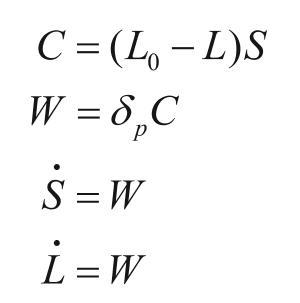

其中C表示焦点国家在时间t时的初始冲突水平（Hanneman et al.在注释中使用的是C<sub>t</sub>），L表示正当性程度（Hanneman et al.在注释中使用的是L<sub>t</sub>，也可用PR<sub>t</sub>表示），W表示当时参与战争的结果（Hanneman et al.在注释中使用的是WS<sub>t</sub>）。S表示过去在战争中取得胜利和失败的累积记录（Hanneman et al.在注释中使用的是CS<sub>t</sub>）。参数L<sub>0</sub>表示正当性方面的目标（Hanneman et al.在注释中使用的是LG），δ<sub>p</sub>(＝(E-EP)/(P+EP))是焦点国家与其对手之间的实力差距。用C和W的关系替换微分方程中的L后，得到以下方程：

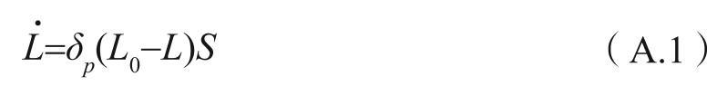

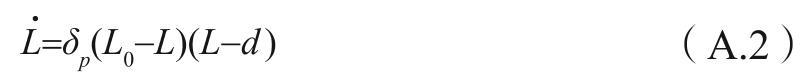

这从本质上属于logistic模型（如果d=0，那么它恰好是一个logistic模型）。看起来它的动态与Hanneman et al.（1995，第21—24页）的模拟研究得出的行为完全匹配。

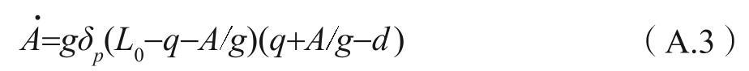

这个过程还没有结束，因为从实力差（power differential）δ<sub>p</sub>得出函数

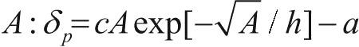

（请参见第2.2.1）。我们使用这个关系得出了最终结果：

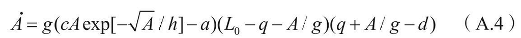

## A.2 边境假设的空间模拟

我们在21×21格组成的空间“舞台”上开展了模拟分析。每格代表一个规模较小的地区政权或幅员辽阔的帝国的一个省份（因此，它们的空间分辨率极其粗糙）。这项模拟分析假设存在两个空间层次（即单个格子代表的地区和多个格子代表的帝国）。首先，我们将一个占领多个格子的帝国放在模拟区上的某处（譬如，这个帝国占据了4×4的正方形区域）。每个格子都涉及两个数字：帝国指数（表明这个格子属于哪个帝国）和群体感值。模拟研究刚开始时，属于第一个帝国的格子被赋予指数1，而其他格子的指数为0（相当于不属于任何帝国的腹地）。

每个格子的群体感值代表了该地区的居民对于他们认为自己应该归属的跨地区帝国所感受到的团结程度平均值（如果这个格子的帝国指数为0，那么它的群体感值表明它是地区政权）。群体感动态取决于这个格子相对于王朝边界的位置。如果这个格子紧邻王朝边界（即与它相邻的格子中有一个格子的帝国指数与它不同），那么它的群体感值会根据以下规则有所提升：

S<sub>x,y,t</sub><sub>+1</sub>＝S<sub>x,y,t</sub>+r<sub>0</sub>S<sub>x,y,t</sub>(1-S<sub>x,y,t</sub>) （A.5）

S<sub>x,y,t</sub><sub>+1</sub>＝S<sub>x,y,t</sub>-δS<sub>x,y,t</sub> （A.6）

请注意，一个格子的相邻区域被定义为与它共用线性边界的另外四个格子（这不包括在它的对角线延长线上，仅仅触及它的四角的四个格子）。此外，对于那些不属于任何帝国、处于腹地的格子，只有它们邻近一个帝国时，我们才认为它们位于边界上。

区域性帝国的特点用以下两个数字来表示：它们所控制的区域数量A<sub>i,t</sub>和群体感的平均值，

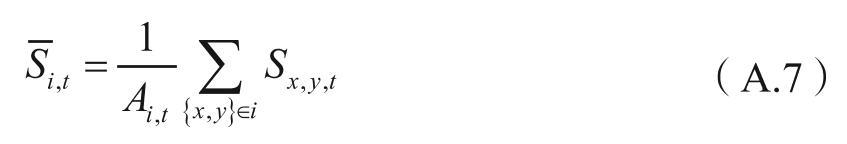

i在这里表示帝国指数。

在每个时间步，每个格子都会考虑攻击自己的四个邻居。如果它的邻居和它属于同一个帝国，那么就不会出现攻击（但不属于任何帝国、处于腹地的格子会相互攻击）。它们的攻击成功与否取决于进攻格子的实力P<sub>att</sub>相对于防御格子的实力P<sub>def</sub>的情况。我们使用以下方程式计算格子x和y在时间点t的实力：

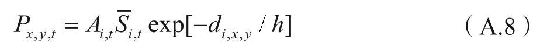

为了确定攻击的成功程度，我们对比了攻击者和防御者的实力。如果出现以下情况：

P<sub>att</sub>-P<sub>def</sub>>Δp （A.9）

那么这次进攻取得胜利，采取守势的格子被占领，它的帝国值也相应变成进攻它的帝国的数值。被占领的格子的群体感值被重设为它被攻占前的群体感值与攻击它的格子的群体感值的平均值。如果这次进攻铩羽而归，那么一切都没发生改变。参数Δp是确保进攻取得成功的最低实力差。

以下列出了这项模拟研究的部分技术要点。（在一个时间步中）格子成为潜在攻击者的顺序是随机的，而且攻击顺序在每次时间步中都会发生变化。这么做避免了按照固定顺序选择攻击者时产生的所有系统性定向偏差。同样，与它相邻的四个格子在每个时间步中也按照随机顺序发动进攻。这两个随机化处理是随机性影响模型动态的唯一途径，否则所有影响都具有确定性。这项模拟研究中的边界条件具有反射性。我们认为这个“舞台”边角处的格子不会攻击相邻地区，而且在每个时间段行将结束时，它们的群体感值和帝国值都被重新设定为与其最接近的非边界格子的值。

这个模型极其简单，只包含了五个可以确定其行为的参数。参数的参考集包括r<sub>0</sub>＝0.2、δ＝0.1、h＝2、Δp＝0.1和S<sub>erit</sub>＝0.003。我们可以以它们为起点来探索相关动态。

## A.3 纳入了阶级结构的人口-结构模型

为资源攫取行为建模

我首先研究了平民和精英之间的互动，涉及的结构变量包括：生产者群体（即农民和平民）的规模P和剥削者群体（即精英和贵族）的规模E。我们假设每位生产者的平均产量与生产者群体的规模成线性函数ρ＝ρ<sub>0</sub>（1-gP）。参数ρ<sub>0</sub>衡量了每位生产者的最高粮食生产率。参数g量化了人均产量如何随着生产者群体的扩张下滑。为了将产量与人口动态关联起来，我假设生产者人口增长的人均增长率r<sub>p</sub>与每位生产者可获得的资源ρ<sub>p</sub>成线性函数：

r<sub>p</sub>＝β<sub>1</sub>ρ<sub>p</sub>-δ<sub>1</sub> （A.10）

这个方程式意味着如果ρ<sub>p</sub>>δ<sub>1</sub>/β<sub>1</sub>，那么生产者群体的规模会扩大；否则会下降。参数β<sub>1</sub>可以被视为将过剩产量转化为婴儿的系数，而δ<sub>1</sub>也是粮食匮乏时，农民们相继死亡的速度。

如果生产者把自己生产的所有资源都消耗光（即ρ<sub>p</sub>＝ρ），那么可以用以下方程式来描述他们的人口动态：

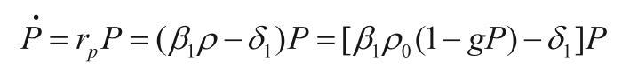

然而，出现了剥削者后，生产者无法再将自己生产出来的粮食都留在自己手里。现在我们需要推导出一个模型来描述剥削者攫取资源的情况。这个模型的要素是剥削者能够对生产者施加的高压政治的强度。我假设剥削者人数较少时，他们能够产生的高压政治的强度（以及由此从生产者那里攫取的资源比例）与剥削者的人数成正比：aE。然而，随着E的上升，剥削者所攫取的资源不可能超过总产量。我相应地假设剥削者攫取到的资源在资源总量中的比例取决于双曲线函数aE/(1+aE)。附带提一句，我们还可以研究剥削者如何管控有生产者居住的领土，从而更加机械地推导出这个函数。那么，参数a成为一个剥削者可以管控的土地规模的上限。请注意，这个公式假设在极限情况下，随着剥削者的人数上升，被攫取的产量的比例趋近于一。为了推导出通用性更强的模型，我们将被攫取资源的比例设定为aE/(1+aE)。其中新参数∈表示从生产者那里攫取的产量的比例上限。

总攫取率是被攫取的产量比例乘以总生产率得出的结果（相应地，这本身是用人均生产率与生产者人数计算后得出的结果）：

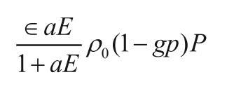

留给生产者的产量为：

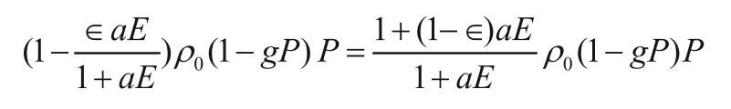

我们用被攫取的资源量除以剥削者人数，再用留给生产者的资源除以生产者人数，分别得出剥削者和生产者获得的人均资源量：

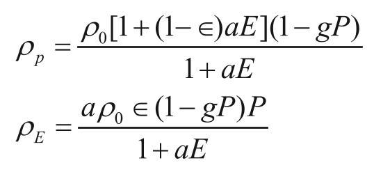

我们用这个方程式替换A.10中ρ<sub>p</sub>的后得到了生产者方程式：

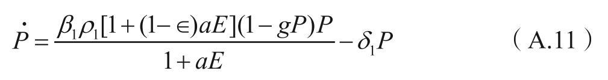

我们用同样的方法推导出剥削者的人口动态：

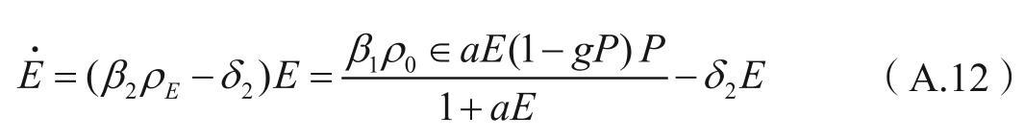

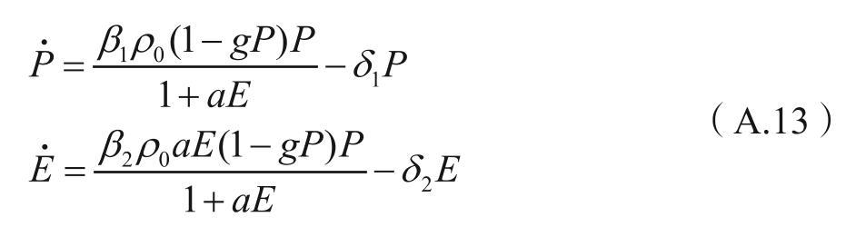

这些方程式描述了精英阶层残酷无情时的情况。他们准备从农民身上剥削到尽可能多的产量，而不考虑会对农民的人口动态造成什么影响。

纳入了阶层结构的人口-财政模型

既然我们已经有方程式将P和E连接在一起，那么就可以利用它们来调整基本人口-财政模型。我采用了简化模型——方程式A.13——来描述P和E的动态。参数g确定了不存在精英时生产者的承载力。我假设它与S的函数关系与基本人口-财政模型中假设的情况完全一致。

现在我们需要用一个方程式来描述国家资源S。在财政收入方面，被攫取的资源中应该有一部分以税收的形式通过剥削者交给国家。我假设精英从生产者那里攫取的资源足以维持自己的消费水平并达到自己的预期，那么他们会将剩下的产量分享给国家。然而，如果剥削者获得的资源不足以维持他们及家人的生活，那么他们会团结起来抵制国家增加税收的需求。他们的抵制行为可以表现为以下形式：集体反对国家的需求，或官员采取个体行为，挪用越来越多的税收来满足私欲。无论他们选择哪种形式，最终结果都是精英日渐困顿，从生产者那里攫取到的产品中分给国家的比例越来越小。

接下来，我利用基本模型进行推导，假设国家必须为剥削者提供政府官员、官僚和牧师等职位，所以国家支出随着剥削者的人数呈线性增长。这个观点假定与精英对国家提出的需求相比，生产者人口增长造成的国家支出可以忽略不计。（当然我们可以在模型中增加与生产者支出相关的变量，但这会使模型复杂化，而且不会改变它的主要结果。）把我们对收支的假设组合在一起，得出了以下关于S的方程式：

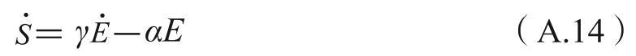

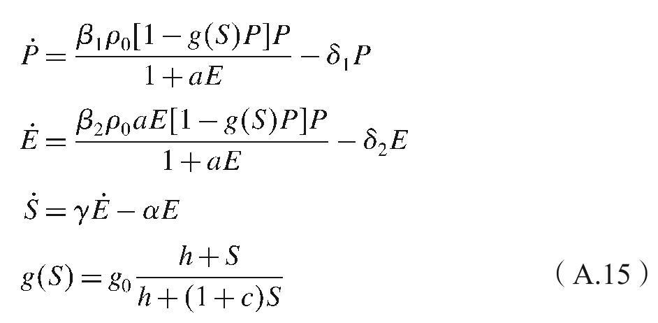

“自私精英”模型

我假设存在强大的国家时，会强迫精英处于和平状态。相反，不存在国家或国力羸弱时，精英的内部竞争会以暴力形式表现出来，结果提升了精英的灭绝率。换言之，我认为方程式A.12中的参数δ<sub>2</sub>应该表现为S的衰减函数。我假设存在双曲线函数δ<sub>2</sub>＝c<sub>1</sub>/(1+c<sub>2</sub>S)。在这个函数中，c<sub>1</sub>表示最高灭绝率。它会在S=0时出现。c<sub>2</sub>这个参数用来衡量灭绝率随着S上升而下降的速度。对δ<sub>2</sub>的另外一个研究角度是将它视为代表精英内部竞争的系数。随着国家资源量S逐渐下降，精英为之争斗的蛋糕也不断缩水，结果激化了精英内部的竞争，导致精英的死亡率上升，流动性下降。请注意，我们通过对δ<sub>2</sub>建立与S有关的函数，而不是与E有关的函数，将时间滞差纳入了精英人数对其自身的反馈效应。精英人数增加本身没有加剧精英的内部竞争，而是降低了国家的财政健康水平，间接影响精英动态。它的方程式如下（为了简化研究，我再次将∈的值设定为0）：

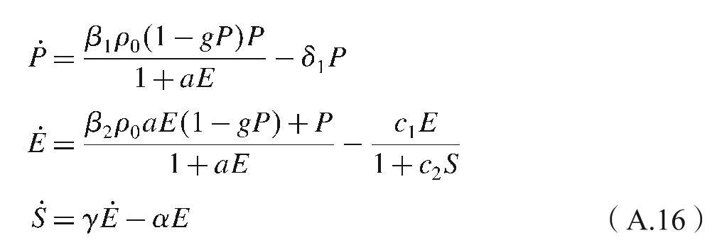

我将这个模型称为“自私精英”模型，因为精英残酷压榨平民，完全不顾他们的幸福康乐。此外，如果精英有足够的生活资源，那么会把部分税收转交国家。（当然，即使在人口-财政模型中纳入阶级结构，精英的表现也没有变化。我仍然需要某些方便的标签来指代这些模型，而且这个模型和其他模型效果相当）。

利用这个模型进行分析时，将它按比例放大或缩小会有利于推动研究。为此，我定义了一些新的变量P'＝gP： E'＝aE和S'＝c<sub>2</sub>S。按比例调整后的方程式如下：

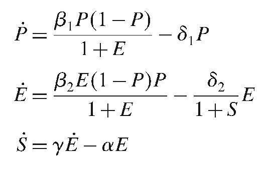

和之前一样，我控制了质数来提高它的可读性。

## A.4 精英周期模型

伊本·赫勒敦模型

我们用R来指代从平民那里攫取的资源的数量，它是个常量。精英的人均收入μ取决于以下演算：

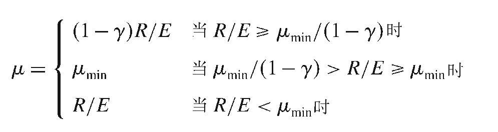

精英群体的人均变化率如下：

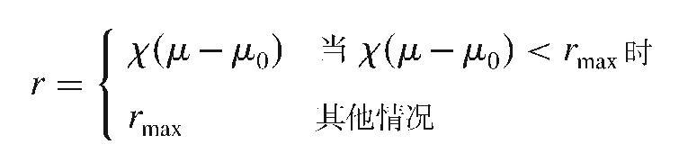

我们假设S≥0，为E、S和μ<sub>min</sub>列出以下动态方程式：

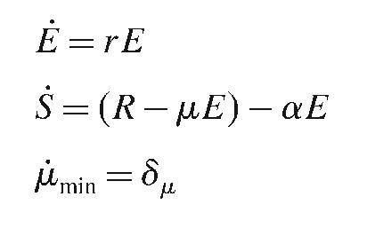

如果S＜0，那么我们设定E＝E<sub>0</sub>，S＝0且μ<sub>min</sub>＝μ<sub>0</sub>，然后重复整个周期。

纳入阶级结构的伊本·赫勒敦模型

平民的人均收入情况如下：

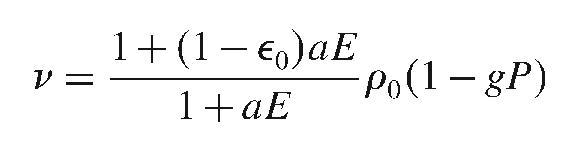

从平民那里攫取到的资源数量如下：

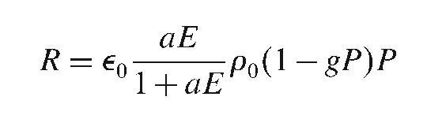

我们采用简版伊本·赫勒敦模型中的方法计算了精英的人均收入μ：

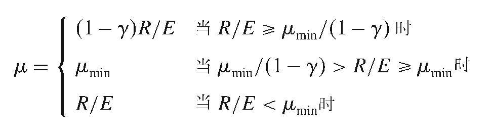

同样，我们利用这个方法计算了精英族群的人均变化率：

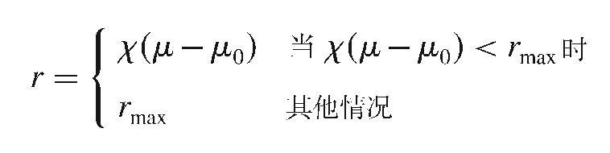

最终得到的动态方程式如下：

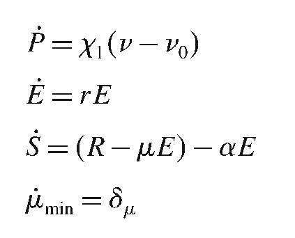

如果S＜0，那么我们设定E＝E<sub>0</sub>，S＝S<sub>0</sub>且μ<sub>min</sub>＝μ<sub>0</sub>，然后重复整个周期。

寄生性游牧民族模型

它们从农业国家攫取的资源数量如下：

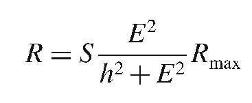

精英的人均收入如下：

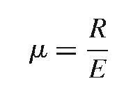

我们计算精英族群的人均变化率时采用了伊本·赫勒敦模型中的计算方法，得出的结果如下：

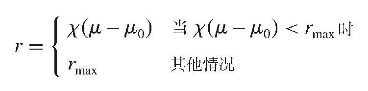

（假设S≥0）我们得到的动态方程式如下：

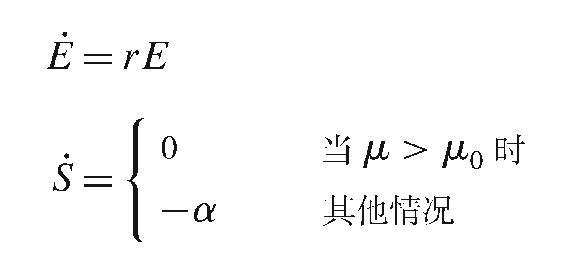

如果S＜0，那么我们设定E=E<sub>0</sub>，S=S<sub>0</sub>，然后重复整个周期。

# 附录B 元民族边境理论中的数据汇总

## B.1 “文化区”的简要描述

ALB 阿尔巴尼亚（Albania）和科索沃（Kosovo）

AND 安达卢西亚（Andalusia）

ANT 安卡拉东部的安纳托利亚［罗马加拉提亚（Roman Galatia）和卡帕多西亚（Cappadocia）］

AQU 阿基坦大区（Aquitaine）［包括加斯科尼（Gascony）、吉耶纳（Guyenne）、普瓦图（Poitou）、利穆赞（Limousain）和佩里戈尔（Perigord）］［罗马阿奎塔尼亚（Roman Aquitania）］

ARG 阿拉贡（Aragon）［包括加泰罗尼亚（Catalonia）和瓦伦西亚（Valencia）］

AUS 奥地利（Austria）［不包括提洛尔（Tyrol）］［罗马诺里库姆（Roman Noricum）］

AZV 亚速海（Azov Sea）以北顿河（Don）和第聂伯河（Dnieper）之间的草原地带［其中包括克里米亚（Crimea）］

BAL 波美拉尼亚（Pomerania）、普鲁士（Prussia）和立陶宛（Lithuania）

BEL 白俄罗斯（Belarus）［基辅公国中的波罗茨克公国（Polotsk）和图罗夫-平斯克公国（Turov–Pinsk）］

BOH 波西米亚（Bohemia）和摩拉维亚（Moravia）

BUL 保加利亚（Bulgaria）和马其顿（Macedonia）［罗马色雷斯（Roman Thracia）和东马其顿（eastern Macedonia）］

BYZ 西安纳托利亚（Western Anatolia）和欧洲土耳其（European Turkey）［罗马亚洲（Roman Asia）和比提尼亚（Bythinia）］

CAS 卡斯提尔（Castile）、利昂（Leon）［不包括加利西亚（Galicia））和纳瓦拉（Navarre］

CRU 俄罗斯中部［罗斯公国的弗拉基米尔（Vladimir）–苏兹达尔（Suzdal）］

DAL 克罗地亚（Croatia）、波斯尼亚（Bosnia）和斯洛文尼亚（Slovenia）［罗马达尔马提亚地区（Roman Dalmatia）伊利里亚行省（Illyricum）的北部］

DEN 丹麦（Denmark），包括石勒苏益格（Schleswig）和荷尔斯泰因（Holstein）

EFR 香槟地区（Champaigne）、洛林（Lorraine）、阿尔萨斯（Alsace）、勃艮第（Burgundy）和法国瑞士（French Switzerland）［大体上等于罗马上日耳曼尼亚（Roman Germania Superior）再加上卢古德南锡斯（Lugdunensis）东部］

EGE 原东德（Former East Germany）［勃兰登堡（Brandenburg）和萨克森（Saxony）］

EPL 波兰（Poland）东部，中心位于华沙（Warsaw）［马索维亚（Mazovia）和小波兰（Little Poland）］

FIN 芬兰（Finland）

GAL 乌克兰（Ukraine）西部［加利西亚和沃里尼亚（Volhynia）］

GRE 希腊（Greece）

HUN 匈牙利（Hungary）、斯洛伐克（Slovakia）和伏伊伏丁那（Vojvodina）［罗马潘诺尼亚（Pannonia）再加上多瑙河（Danube）和提萨河（Tisza）之间的土地］

IRL 爱尔兰（Ireland）（整个爱尔兰岛）

KAZ 喀山（Kazan）［大保加利亚（Great Bulgar）和喀山汗国（Kazan Khanate）］

MOL 摩尔多瓦（Moldova）［即比萨拉比亚（Bessarabia）］和罗马尼亚（Romania）摩尔达维亚省（Moldavia）

NBL 拉脱维亚（Latvia）和爱沙尼亚（Estonia）

NBR 苏格兰（Scotland）

NED 荷兰（Netherlands）、比利时（Belgium）、卢森堡（Luxemburg）和莱茵兰（Rhineland）［罗马比利时（Belgica）北部和下日耳曼尼亚（Germania Inferior）］

NFR 法兰西岛（Ile-de-France）、皮卡第（Picardy）、诺曼底（Normandy）、布列塔尼（Brittany）、昂儒（Anjou）、都兰（Touraine）、奥尔良（Orléannais）［罗马卢古德南锡斯（Lugdunensis）西部和比利时（Belgica）南部］

NOR 挪威（Norway）

NOV 诺夫哥罗德（Novgorod）的领土、普斯科夫（Pskov）和英格里亚（Ingria）

NRU 俄罗斯北部［沃洛格达（Vologda）、维亚特卡（Vyatka）和北部土地］

POR 葡萄牙（Portugal）和加利西亚

SBR 英格兰（England）和威尔士（Wales）

SER 塞尔维亚（Serbia）（不包括伏伊伏丁那）和黑山共和国（Montenegro）［罗马上梅西亚（Roman Moesia Superior），是达尔马提亚（Dalmatia）的一部分］

SFR 图卢兹（Toulousain）、普罗旺斯（Provence）、奥弗涅（Auvergne）、萨瓦（Savoy）［罗马纳尔博南西斯（Roman Narbonensis）］

SGE 斯瓦比亚（Swabia）、巴伐利亚（Bavaria）、德国瑞士（German Switzerland）、提洛尔（Tyrol）［罗马莱蒂亚（Roman Rhaetia）和日耳曼领土以北］

SIT 罗马以南的意大利领土［包括拉齐奥（Lazio）］

SRU 俄罗斯南部（即“黑土区”）

SWE 瑞典（Sweden）

TRA 特兰西瓦尼亚（Transylvania）［罗马达西亚（Roman Dacia）］

UKR 乌克兰（Ukraine）中部［基辅（Kiev）、切伦科夫（Chernigov）、诺夫哥罗德–谢韦尔斯克（Seversk）、佩雷雅斯拉夫（Pereyaslavl）］

VLG 伏尔加河（Volga）下游流域，KAZ以南［从萨拉托夫（Saratov）到阿斯特拉罕（Astrakhan）］

VLH 瓦拉吉亚（Wallachia）：不包括特兰西瓦尼亚（Transylvania）和摩尔达维亚（Moldavia）等省份的现代罗马尼亚（Romania），但包括多布罗加（Dobrudja）［罗马下梅西亚（Roman Moesia Inferior）再加上多瑙河（Danube）以北的土地］

WGE 法兰克福（Frankfurt）以北的原西德（West Germany）领土（包含法兰克福）

WPL 波兰西部，中心位于克拉科夫市（Cracow）［即大波兰（Great Poland）］和西里西亚（Silesia）

WRU 俄罗斯（Russia）西部［即斯摩棱斯克公国（Principality of Smolensk）］

ZAP 扎波罗热（Zaporozhie）（乌克兰南部）

## B.2 边境的量化研究

本节用大写字母表示文化区的代码，用罗马数字代表世纪（如“Ⅲ”代表“3世纪”）。

（在皈依基督教之前）罗马帝国边境的典型得分如下：地区=1（存在无排他性的异教）；语言=2（拉丁语vs.凯尔特语、日耳曼语和伊利里亚语等语言）；经济=1（住在城市的务农者vs.住在边远地区的务农者）；压力=1（会受到突袭，边境人口没有减少）——这些分数加起来的总分为5。

ANT：深处罗马帝国的腹地，没有边境（公元3世纪和6世纪，国家行将崩溃时经常受到袭击的情况除外），在1世纪至6世纪，它的分数为0。在7世纪至11世纪，拜占庭-哈里发（Caliphate）边境的分数为3+2+1+2＝8。拜占庭帝国经过曼齐刻尔特（Manzikert）一战被突厥攻占后，它在12世纪至14世纪的分数为3+2+2+2＝9。从15世纪开始，奥斯曼帝国中心的分数为0。

AQU：一个罗马行省：在公元1世纪至6世纪，它的分数为0。在418年：西哥特人（Visigoths）建立了图卢兹王国（Kingdom of Toulouse）（该王国一直持续到507年）（Wolfram，1997，第xvii页）。在507年：法兰克人占领了这个地区。在587年：历史资料中首次出现Vascone人进攻阿基坦南部平原并掳走当地民众的记录（Collins，1990，第84页）。在7世纪，巴斯克人的定居点逐渐蔓延至阿基坦南部平原（Collins，1990，第96页），它的分数是3+2+1+1=7。在整个7世纪，巴斯克人一直属于异教徒（Collins，1990，第104页）。到了8世纪中叶，生活在比利牛斯山（Pyrenees）以北的巴斯克人基本已经被基督教化（Collins，1990，第152页）。8世纪时它的分数为1+2+1+1＝5。9世纪以后不再是重要的边境。

ARG：一个罗马行省：在1世纪至5世纪的分数为0。在6世纪，巴斯克人给西哥特统治者带来不少麻烦。在6世纪和7世纪，巴斯克人经常侵犯埃布罗河（Ebro）谷地的城镇。它的分数为3+1+1+1＝6（我们不确定山地人和低地人是否使用不同的语言）（Collins，1990，第82—98页）。在整个7世纪，巴斯克人一直属于异教徒（Collins，1990，第84页）。在伊比利亚的基督教/伊斯兰教边境，它在8世纪至12世纪的分数为3+2+1+2=8。边境消失后：它在13世纪以后的分数为0。

AUS：一个罗马行省：在1世纪至2世纪，它的分数为0。在纷争不断的3世纪，罗马边境逐渐南移：日耳曼人入侵后，它在3世纪的分数为5，在4世纪的分数为7（当时出现了基督教化），在5世纪的分数为8（当时出现了人口减少的情况）。在法兰克-阿瓦尔边境：它在6世纪至7世纪的分数为1+2+2+1＝6，在8世纪的分数为3+2+2+2＝9，在9世纪的分数为3+2+1+1＝7。马扎尔人入侵后，10世纪时它的分数为3+2+2+2＝9。随着马扎尔人被基督教化，11世纪它的分数为2+2+1+1＝6；在12世纪至15世纪，它的分数为0+2+0+0＝2。位于奥斯曼帝国边境时，16世纪至18世纪它的分数为3+2+1+2＝8。

AZV：位于博斯普鲁斯王国（Bosporan Kingdom）与大草原之间的边境：在1世纪至2世纪，它的分数为1+2+2+1=6。在375年左右，匈奴人穿过顿河（Wolfram，1997，第123页）。后来它成为不受任何国家管控的偏远地区，在3世纪至6世纪的分数为0。它的草原部分被纳入可萨汗国的版图后（Farrington，2002，第83—85页），成为拜占庭帝国在克里米亚半岛的边境：在7世纪至10世纪，它的分数为3+2+2+0＝7。后来位于拜占庭-草原与佩切涅格人（Pecheneg）、库曼人（Cuman）和蒙古人（Mongol）之间的边境：在11世纪至14世纪，它的分数为3+2+2+1＝8。成为克里米亚鞑靼人的中心后，它在15世纪至16世纪的分数为0。随后位于与俄罗斯的边境：在17世纪和18世纪的绝大多数时间里，它的分数为3+2+2+1＝8。1783年被俄罗斯吞并。

BAL：属于不受任何国家管控的偏远地区：在1世纪至10世纪的分数为0。基督教化的基辅罗斯对它施加了不少压力（如受到袭击或被迫向基辅罗斯纳贡）（Gudz-Markov，1997，第413页）：在11世纪至12世纪，它的分数为3+2+1+1＝7。日耳曼人“东进”运动（Drang nach Osten）进入波美拉尼亚（Pomerania）、普鲁士（Prussia）和立陶宛后：它在13世纪和14世纪的分数为：3+2+1+2＝8。在1386年至1417年：立陶宛皈依基督教（Palmer，1957，第53页）并且波罗的海边境关闭：从15世纪开始，它的分数为0。

BEL：属于不受任何国家管控的偏远地区：在1世纪至10世纪的分数为0。于10世纪并入基辅公国（Gudz-Markov，1997，第407页）。随后不再存在明显的边境：在11世纪至12世纪的分数为0。13世纪被蒙古人攻占，14世纪被立陶宛占领，最终于1793年并入俄罗斯：从16世纪开始，它的分数为0。

BOH：在诺里库姆（Noricum）和潘诺尼亚（Pannonia）以北的罗马边境。在1世纪至3世纪，它的分数为5。随后边境逐渐南移，它在4世纪至5世纪的分数为0。在454年至560年：布拉格文化渗入中欧（Gudz-Markov，1997，第28页）。成为不受任何国家管控的偏远地区：它在6世纪至7世纪的分数为0。法兰克人和奥托帝国先后对它施加压力，捷克成了纳贡国；它在8世纪至10世纪的分数为3+2+1+1＝7。在880年至1039年，捷克人皈依了基督教（Palmer，1957，第53页）。这个边境于11世纪关闭：从11世纪开始，它的分数为0+2+0+0＝2。

BUL：在3世纪前一直是罗马行省（分数为0）。从公元238年开始：哥特人对巴尔干半岛（Balkans）和小亚细亚（Asia Minor）的毁灭性攻击持续了一代人的时间（Wolfram，1997，第44页）：它在3世纪的分数为6，在4世纪的分数为7（当时出现了基督教化），在5世纪的分数为8（当时出现了人口下降的情况）。从6世纪开始成为拜占庭与保加尔汗国（Bulgar Khanate）之间的边境：它在6世纪至9世纪之间的分数为8。在863年至900年，保加尔人皈依了基督教（Palmer，1957，第53页）：它在10世纪的分数为0+2+1+0＝3。在11世纪至12世纪，它被拜占庭帝国吞并，分数为0（Reed，1996）。此后成为一个被其他东正教国家所包围的独立国家，但在15世纪末被奥斯曼帝国所征服：它的分数为0。在19世纪之前，它一直是奥斯曼帝国“深入国家腹地”的行省。在11世纪至14世纪，它的分数为0。

BYZ：在3世纪之前，它一直深处罗马帝国腹地：在1世纪至2世纪，它的分数为0。在238年：哥特人对巴尔干半岛和小亚细亚的毁灭性攻击持续了一代人的时间（Wolfram，1997，第44页）。在252年至253年、256年和258年：哥特人先后攻进希腊和亚洲（Le Glay et al.，1997，第393页）。在378年：阿德里安堡（Adrianople）灾难爆发，哥特人站在了君士坦丁堡（Constantinople）的城门下（Wolfram，1997，第307页）。在394年至395年：匈奴人攻击了巴尔干岛上的省份和小亚细亚（Wolfram，1997，第124页）。贝利撒留（Belisarius）从君士坦丁堡的郊区一路追杀库特里格斯人（Kutriguri）（Wolfram，1997，第307页）。在626年，阿瓦尔人/波斯人联合围攻君士坦丁堡，但以失败告终（Wolfram，1997，第xix页）。它的分数在3世纪为6，在4世纪为7，在6世纪至9世纪为8。保加尔人在863年至900年皈依基督教后（Palmer，1957，第53页），10世纪它的分数为0+2+1+0=3。在11世纪，它深处拜占庭帝国的腹地，分数为0。曼齐刻尔特一役结束后，安纳托利亚的大部分土地沦陷，它成为拜占庭帝国与突厥之间的边界：在12世纪至15世纪，它的分数为3+2+2+2=9。随后处于奥斯曼帝国的中心：在16世纪至19世纪，它的分数为0。

DAL：是一个罗马行省：在1世纪至5世纪，它的分数为0。位于阿瓦尔的边境，斯拉夫人从6世纪下半叶开始定居此地：在6世纪，它的分数为（3+2+1+2）/2=4；在7世纪，它的分数为8。后来成为不受任何国家管控的偏远地区：在8世纪至11世纪，它的分数为0。在1100年左右，它被匈牙利人攻占：在12世纪至15世纪，它的分数为0。在15世纪末至16世纪初，它被波斯尼亚人占领，随后奥斯曼帝国将它纳入克罗地亚的版图。在16世纪至19世纪，它的分数为3+2+1+2=8。

DEN：属于不受任何国家管控的偏远地区：在1世纪至6世纪，它的分数为0。随后遭受到斯拉夫侵袭造成的压力：在7世纪至8世纪，它的分数为1+2+1+1=5。后来遭受到加洛林王朝对它施加的压力：在8世纪至10世纪，它的分数为3+1+1+1=6。1035年：丹麦人皈依基督教（Palmer，1957，第53页）。处于基督教-异教边境（即它与瑞典之间的边境。瑞典于1150年皈依了基督教）：在11世纪，它的分数为3+0+1+1=5。12世纪这个边境关闭：它从12世纪开始的分数为0。

EFR：是一个罗马行省：在1世纪至2世纪，它的分数为0。在纷争不断的3世纪，罗马边境逐渐南移：日耳曼人入侵后，它的分数为6；在4世纪的分数为7（当时出现了基督教化）；在5世纪的分数为8（当时出现了人口减少的情况）。西罗马帝国覆灭后，主要的元族群边境消失。只有拉丁语系/日耳曼语系的语言边境仍然残存。从11世纪至19世纪，它的分数为2。

EGE：属于不受任何国家管控的偏远地区：在1世纪至6世纪，在6世纪的某个时间段，斯拉夫人迁徙进入德国中部（Gimbutas，1971，第124页）。随后位于斯拉夫-撒克逊边境上：在7世纪至8世纪，它的分数为1+2+0+0=3。在9世纪，斯拉夫国家受到加洛林王朝的影响（它需向后者朝贡）（Shepherd，1973，第56页）。日耳曼人对斯拉夫领土施加的压力在10世纪变得极其激烈（当时正值亨利一世和奥托一世执政）（Barraclough，1998，第116页）。在983年：斯拉夫人掀起了反对日耳曼人的大规模叛乱（Barraclough，1998，第116页）。沃德人（Wend）在900年至1100年之间皈依了基督教（Palmer，1957，第53页）。在1125年：日耳曼人重新启动它的殖民化进程（Barraclough，1998，第140页）。在9世纪至12世纪，它的分数为3+2+1+1=7。索布人（Sorb）在13世纪信奉了基督教（Palmer，1957，第53页）。在波罗的海的十字军运动中：在13世纪至14世纪，它的分数为3+2+1+1=7。15世纪这个边境关闭：从15世纪开始，它的分数为0。

EPL：属于不受任何国家管控的偏远地区：在1世纪至10世纪，它的分数为0。之后相继被波兰、波兰-立陶宛和俄罗斯吞并；自那之后不再存在明显的边境：从11世纪开始，它的分数为0。

GAL：属于不受任何国家管控的偏远地区：在1世纪至9世纪，它的分数为0。随后被基辅罗斯吞并，之后成为独立的公国，后来被纳入立陶宛-波兰：在10世纪至16世纪，它的分数为0。在那之后处于奥斯曼帝国的边境上［波多里亚（Podolia）曾经短暂地被奥斯曼人占领］：在17世纪，它的分数为3+2+1+1=7。后来边境调头南移：在18世纪，它的分数为0。18世纪末，它被奥地利接管。

GRE：在3世纪之前是深处罗马帝国腹地的一个行省：在1世纪至2世纪，它的分数为0。随后受到哥特人的突袭，在3世纪它的分数为1+2+2+1=6：在4世纪至5世纪，它的分数为0。从540年开始，保加尔人和斯拉文人（Sclavini）持续骚扰色雷斯（Trace）、伊利里亚（Illyria）和塞萨利（Thessaly）（Gimbutas，1971，第100页）。在558年：库特里格尔人（Kutrigur）在斯拉文人的协助下大举入侵马其顿（Macedonia）、希腊和色雷斯（Gimbutas，1971，第100页）。在610年至626年：希腊受到阿瓦尔人和斯拉夫人的进攻（Gimbutas，1971，第103页）。到了7世纪末，斯拉夫人的侵略偃旗息鼓（Gimbutas，1971，第105页）。在6世纪至7世纪，它的分数为3+2+1+2=8。从8世纪至14世纪爆发的反对奥斯曼帝国统治的解放战争，许多帝国先后吞并了它（拜占庭帝国、拉丁帝国和奥斯曼帝国）。它成为深处这些国家腹地的一个行省。在8世纪至17世纪，它的分数为0。

HUN：在1世纪，它成为罗马梅西亚省（Moesia）与实行中央集权的达西亚政权之间的边境。在101年至107年，它被达西亚占领（Le Glay et al.，1997，第271页）。在3世纪，它蒙受野蛮人的侵略（Wolfram，1997，第35页）。在1世纪至3世纪，它的分数为5。它皈依基督教后：在4世纪至5世纪的分数为7。在547年与君士坦丁堡签订的条约中，诺里库姆和潘诺尼亚的部分土地被划给伦巴第人（Langobard）（Wolfram，1997，第xv页）。史料证实第一批斯拉夫人已经与格皮德人和伦巴第人进行过接触（Wolfram，1997，第xx页）。在6世纪，它的分数为1+2+0+1=4。在558年至796年，属于阿瓦尔汗国（Wolfram，1997，第305页）：它在6世纪至8世纪的分数为1+2+2+1=6。在788年至796年：阿瓦尔汗国在反对法兰克人的战争中被彻底摧毁（Wolfram，1997，第xix页）。后来斯拉夫政权开始向加洛林王朝进贡财物（Shepherd，1973，第56页）：它在9世纪的分数为1+2+1+1=5。随后马扎尔人来到这片土地（Barraclough，1998，第111页）：它在10世纪的分数为3+2+2+1=8。在950年至1050年：马扎尔人皈依基督教（Palmer，1957，第53页）：它在11世纪的分数为0+2+1+0=3。它深处匈牙利腹地：在12世纪至15世纪，它的分数为0。最终被奥斯曼帝国占领：它在16世纪至17世纪的分数为3+2+1+2=8。

IRL：在440年至493年皈依基督教（Palmer，1957，第53页）。属于不受任何国家管控的偏远地区：在1世纪至8世纪，它的分数为0。9世纪受到维京人的袭击骚扰。维京人开始定居此地并于841年建立了都柏林王国（Dublin）（Cunliffe et al.，2001，第62页）：它在9世纪的分数为3+2+0+1=6。维京人于10世纪接纳了基督教（Cunliffe et al.，2001，第65页）：它在10世纪的分数为1+2+0+1=4；在11世纪的分数为2（成为语言边境）。在12世纪，维京人的语言被本地的盖尔语彻底同化（Cunliffe et al.，2001，第64页）。边境关闭：它从12世纪开始的分数为0。

KAZ：属于不受任何国家管控的偏远地区：在1世纪至6世纪，它的分数为0。保加尔人与哈扎尔人开战并铩羽而归后，部分保加尔人沿着伏尔加河向北逃亡，抵达KAZ（Artamonov，2001，第243页）：在7世纪至9世纪，它的分数为1+2+2+0=5。伏尔加河流域的保加尔人在10世纪初信奉了伊斯兰教（Artamonov，2001，第635页）：在10世纪至12世纪，它的分数为3+2+2+0=7。1236年它被蒙古人征服（Channon and Hudson，1995，第35页）：它在13世纪至14世纪的分数为0。之后喀山汗国统治此地（即在15世纪初至16世纪末）：在15世纪至16世纪，它的分数为3+2+0+1=6。随后被俄罗斯帝国吞并：它从17世纪开始的分数为0。

MOL：从1世纪开始，它处于下梅西亚（Moesia Inferior）以北的罗马边境：在1世纪至3世纪，它的分数为5。在4世纪，罗马边境向南移动至VLH。公元375年，匈奴入侵。公元562年，阿瓦尔人到达多瑙河下游（Wolfram，1997，第xix页）。后来成为不受任何国家管控的偏远地区：在4世纪至14世纪，它的分数为0。随后位于立陶宛-奥斯曼边境（在15世纪，它位于立陶宛的国界内，之后位于奥斯曼帝国的国界内）：在15世纪至16世纪，它的分数为3+2+0+1=6。

NBL：属于不受任何国家管控的偏远地区：在1世纪至7世纪，它的分数为0。日耳曼人开始远征并攻占了波罗的海；1201年里加（Riga）建城（Barraclough，1998，第140页）：它在13世纪的分数为3+2+1+2=8。在13世纪：爱沙尼亚（Estonia）皈依基督教（Palmer，1957，第53页）。在1309年：库尔兰（Courland）、瑟米利亚（Semgallen）和利沃尼亚（Livonia）被占领。在1346年：爱沙尼亚被占领（Barraclough，1998，第140页）。边境关闭：从14世纪开始，它的分数为0。

NBR：属于不受任何国家管控的偏远地区：它在1世纪的分数为0。短暂侵入罗马边境：在公元81年，阿格利科拉（Agricola）将领土版图推进至福斯-克莱德运河（Forth-Clyde）一线。141年，安东尼努斯（Antoninus）在这里修建了安东尼努斯墙；从159年开始，安东尼努斯墙被逐渐废弃：它在2世纪的分数为1+2+1+1=5。之后属于不受任何国家统治的边远地区：它在3世纪至5世纪的分数为0。5世纪下半叶，达尔里阿达王国（Kingdom of Dalriada）作为阿尔斯特的附属国而成立（Musset，1975，第111页）：它在6世纪的分数为1+1+0+1=3。随后它于563年至597年皈依基督教（Palmer，1957，第53页）。之后属于没有国家统治的边远地区：它在7世纪至8世纪的分数为0。随后位于维京的边境：它在9世纪至10世纪的分数为3+2+1+1=7。皮克特人（Pict）臣服于苏格兰国王肯尼斯一世（macAlpin），成立了一个统一的国家阿尔巴（Alba），随后它更名为“苏格兰”（Scotland）（Musset，1975，第111页）。边境关闭：从11世纪开始，它的分数为0。

NED：被高卢人占领后建立起罗马边境：在1世纪至2世纪，它的分数为5；在3世纪，它的分数增长到6（当时出现了人口减少的情况）；在4世纪，它的分数增长到7（当时皈依了基督教）；在5世纪，它的分数增长到8（当时出现了人口减少的情况）。后来位于撒克逊边境：在6世纪至8世纪，它的分数为3+0+1+1=5。边境关闭：它的分数从9世纪开始为0。

NIT：是一个罗马行省：在1世纪至4世纪，它的分数为0。随后野蛮人入侵，在405年：东哥特人（Ostrogoths）首领拉达盖苏斯（Radagaisus）入侵意大利（Wolfram，1997，第xvi页）；在452年：匈奴通过潘诺尼亚入侵意大利，占领了阿奎莱亚（Aquilea）、帕维亚（Pavia）和米兰（Milan）（Wolfram，1997，第138页）。在493年：东哥特人的领袖狄奥多里克（Theodoric）夺取了拉韦纳（Ravenna）；在497年：东哥特王国被东罗马帝国承认（Wolfram，1997，第xvii页）：它在5世纪的分数为3+2+1+2=8。之后不再存在明显的边境：从11世纪开始，它的分数为0。

NOR：属于不受任何国家管控的偏远地区：在1世纪至8世纪，它的分数为0。后来位于加洛林王朝边境的外缘区域：在9世纪至10世纪，它的分数为3+1+1+1=6。到了公元1000年，它信奉了基督教（Palmer，1957，第53页）。随着基督教化的进程不断推进，边境关闭：从11世纪开始，它的分数为0。

NRU：属于不受任何国家管控的偏远地区：在1世纪至5世纪，它的分数为0。它先后被诺夫哥罗德和俄国吞并：从11世纪开始，它的分数为0。

SBR：1世纪被罗马攻占后成为罗马的边境（Le Glay et al.，1997，第216页）：在1世纪，它的分数为5。在2世纪，这个边境向NBR移动：它在2世纪的分数为0。2世纪末安东尼墙被逐步废弃后，边境又回到SBR北部［即建造于122年的哈德良长城（Hadrian wall）］：在3世纪，它的分数为5。在4世纪，它的分数上升至6（当时皈依了基督教）。皮克特人和撒克逊人首次于429年入侵这里（Wolfram，1997，第xx页）。在430年至440年间，日耳曼人有规律地流入不列颠（Musset，1975，第101页）：在5世纪至6世纪，它的分数为3+2+1+2=8。到了670年，盎格鲁-撒克逊人皈依了基督教（Palmer，1957，第53页）：在7世纪，它的分数为2+2+1+1=6；在8世纪，它的分数为0+2+1+0=3。随后维京人入侵：在9世纪至10世纪，它的分数为3+1+1+1=6。在那之后，边境关闭：从11世纪开始，它的分数为0。

SER：是一个罗马行省：在1世纪至4世纪，它的分数为0。在4世纪末，东罗马帝国的边境南移至SER：在5世纪和6世纪，它的分数为3+2+1+2=8。南斯拉夫人在草原上与阿瓦尔人、保加尔人和马扎尔人比邻而居：在9世纪至10世纪，它的分数为1+2+2+1=6。在10世纪，塞尔维亚人皈依基督教（Palmer，1957，第53页）：它在10世纪的分数为7。（950年至1050年）匈牙利人信奉基督教后（Palmer，1957，第53页）：在11世纪至14世纪，它的分数下降至0+2+0+0=2。在14世纪末至15世纪初，它被奥斯曼帝国占领；SER位于奥斯曼帝国的边境：在15世纪，它的分数为3+2+2+2=9。随后边境北移：在16世纪至17世纪，它的分数为0。在18世纪至19世纪，它的分数为3+2+1+1=7。

SFR：是一个罗马行省：在1世纪至5世纪，它的分数为0。那之后不再存在明显的边境：从11世纪开始，它的分数为0。

SGE：被高卢人占领后成为罗马边境：在1世纪至2世纪，它的分数为5；在4世纪，它的分数为7（当时皈依了基督教）；在5世纪，它的分数为8（当时出现了人口减少的情况）。处于法兰克人的边区：在6世纪至8世纪，它的分数为3+2+1+1=7。随后边境关闭，它的分数从9世纪开始为0。

SIT：位于罗马的中心：在1世纪至5世纪，它的分数为0。随后被东哥特人、伦巴第人、法兰克人和拜占庭人占领：在6世纪至8世纪，它的分数为0。随后持续受到萨拉森人（Saracen）的攻击：在9世纪，它的分数为3+2+1+1=7。它先后被日耳曼人和西班牙人占领，之后成为独立的国家［即那不勒斯王国（Kingdom of Naples）］：从10世纪开始，它的分数为0。在9世纪至10世纪，穆斯林占领了西西里后展示出一个很有意思的问题。然而，西西里被日耳曼人占领后，之前定居在这里的穆斯林被赶出西西里。利古里亚（Liguria）、托斯卡纳（Tuscany）和普罗旺斯（Provence）的居民被安置到西西里安家落户（Abulafia，1990）。

SRU：属于不受任何国家管控的偏远地区：在1世纪至6世纪，它的分数为0。斯拉夫人（即它的Vyatichi部落）从8世纪开始在它的北部安家落户，导致乌戈尔人（Ugric）在随后的五个世纪里被逐步同化。后来位于与喀山和伏尔加河流域保加尔人毗邻的草原边境上：在7世纪至10世纪，它的分数为1+2+2+1=6。皈依基督教后：在10世纪至12世纪，它的分数为3+2+2+1=8。遭受蒙古人的入侵和鞑靼人的袭击后，人口减少：在13世纪至16世纪，它的分数为3+2+2+2=9。随后边境南移：从17世纪开始，它的分数为0。

SWE：属于不受任何国家管控的偏远地区：在1世纪至7世纪，它的分数为0。从公元800年开始，它处于加洛林王朝的边境外缘。从829年至1150年，瑞典一直承受着皈依基督教的压力，而且这个时期漫长得异乎寻常（Palmer，1957，第53页），由此激发了北欧异教徒的强烈反应：在9世纪至12世纪，它的分数为3+1+1+1=6。皈依基督教后，边境关闭：从13世纪开始，它的分数为0。

TRA：在1世纪，它成为罗马梅西亚省与实行中央集权的达西亚政体之间的边境。在101年至107年，它被达西亚占领（Le Glay et al.，1997，第271页）。在3世纪，它遭受了“蛮族”的入侵（Wolfram，1997，第35页）。在1世纪至3世纪，它的分数为5。随后处于匈奴帝国、格皮德王国、阿瓦尔汗国、保加尔汗国和马扎尔帝国的腹地。在喀尔巴阡山（Carpathian Mountains）的保护下，它没有直接受到大草原的影响：在4世纪至15世纪，它的分数为0。随后被奥斯曼帝国占领：在16世纪至17世纪，它的分数为3+2+1+1=7。18世纪，它处于奥匈帝国的国界内：它的分数为3+2+0+1=6。

UKR：属于不受任何国家管控的偏远地区：在1世纪至6世纪，它的分数为0。后来处于哈扎尔边界上：在7世纪至8世纪，它的分数为1+2+2+1=6；在9世纪至10世纪，它的分数为3+2+2+1=8［在740年至861年，可萨人皈依了犹太教（Farrington，2002，第82页）］。在988年至1015年，它皈依了基督教（Palmer，1957，第53页）。后来位于基辅罗斯-草原边境上：在11世纪至12世纪，它的分数为3+2+2+1=8。随后人口减少：在13世纪至16世纪，它的分数为3+2+2+2=9。最终边境南移：从17世纪开始，它的分数为0。

VLH：位于达西亚的边境上：在1世纪，它的分数为1+2+1+0=4。后来边境北移：在2世纪，它的分数为0。在纷争不断的3世纪，罗马边境南移；野蛮人入侵；在3世纪，它的分数为1+2+1+2=6。在4世纪至5世纪，它的分数为3+2+1+1=7（当时皈依了基督教）。后来处于阿瓦尔-拜占庭边境上：在6世纪至7世纪，它的分数为3+2+2+2=9（当时出现了人口减少的情况）。在679年：保加尔人穿过多瑙河；在681年：拜占庭帝国承认了保加尔汗国的地位（Hupchik and Cox，1996，第8页）。后来处于拜占庭-保加尔边境上：在8世纪，它的分数为3+2+2+1=8。在802年：保加利亚四处扩张，削除了VLH的边境（Hupchik and Cox，1996，第10页）：在9世纪至10世纪，它的分数为0。在972年，多布罗加（Dobrudja）被拜占庭吞并（Hupchik and Cox，1996，第12页）。在拜占庭-草原边境上（即佩切涅格人和库曼人的边境上）：在11世纪至12世纪，它的分数是3+2+2+1=8。在保加利亚-草原边境上（即与库曼人和蒙古人的边境上）：在13世纪，它的分数为3+2+2+1=8。在14世纪，瓦拉吉亚（Wallachia）被信奉基督教的国家所包围［即匈牙利、摩尔达维亚（Moldavia）和保加利亚］：它的分数为0+2+0+0=2。在1393年：瓦拉吉亚（Wallachia）成为奥斯曼帝国的一个藩国（Hupchik and Cox，1996，第22页）。后来它位于奥斯曼帝国与匈牙利的边境上：在15世纪，它的分数为3+2+1+1=7。1526年的默哈克（Mohac）战役后，匈牙利的大半领土被土耳其占领，边境北移：在16世纪至17世纪，它的分数为0。到了18世纪，它重回奥匈帝国/奥斯曼帝国的边界：它的分数为3+2+0+1=6。

WGE：被高卢人占领后成为罗马的边境：在1世纪至3世纪，它的分数为5。后来边境南移；在4世纪至5世纪，它的分数为0。随后它位于法兰克帝国的边境上：在6世纪至8世纪，它的分数为3+1+1+1=6。随后位于斯拉夫人的边境：在9世纪至12世纪，它的分数为3+2+1+1=7。随着EGE在12世纪落入殖民者手中，最后的斯拉夫人改变信仰（即13世纪的索布人）。边境关闭：它的分数从13世纪开始为0。

WRU：属于没有国家统治的边远地区：在1世纪至6世纪，它的分数为0。在7世纪至8世纪，大批斯拉夫人［即克里维奇人（Krivichi）］迁徙到这里（Gudz-Markov，1997，第422页）。WRU位于东斯拉夫人定居区的中心：它的分数为0。在公元1000年左右，它开始信奉基督教。之后先后被蒙古人、立陶宛人和俄罗斯人征服。自此不再出现明显的边境：从13世纪开始，它的分数为0。

ZAP：在1世纪，是博斯普鲁斯王国（Bosporan Kingdom）与大草原之间的边境；在2世纪至3世纪是罗马边境的延长部分：在1世纪至3世纪，它的分数为1+2+2+1=6。随后成为东哥特王国的腹地：在4世纪，它的分数为0。在375年左右，匈奴人入侵（Wolfram，1997，第123页）。它成为草原的腹地（草原先后被匈奴、保加尔人、马扎尔人、佩切涅格人、库曼人和蒙古人占领）：在5世纪至14世纪，它的分数为0。14世纪末，它被立陶宛吞并（Reed，1996）。位于（1）波兰-立陶宛和（2）俄国与克里米亚汗国和奥斯曼帝国之间的边境上：在15世纪至18世纪，它的分数为3+2+2+2=9。

[figure not shown]

## B.3 对政权规模的量化：公元后第一个千年

我研究500年至1000年欧洲政权的规模时采用的主要资料来源是《欧洲历史地图集》杂志（Periodical Historical Atlas of Europe）光盘（Nüssli，2002）。这个地图集列出了数以百计政权，但我们只对它们的一个子集感兴趣。首先，我们忽略了领土面积的最大规模不超过0.1的所有政权——我们已经在第5.1.2节探讨了这么做的原因。

第三，我们需要将两类政权区分开来：一类政权在发源地不断发展壮大；另一类政权则由四处游走的民族建立（在公元500年至1000年，第二类政权出现得尤为频繁）。我在本书划分了三类政权。其中最容易认定的政权是阿瓦尔汗国、哈里发国和马扎尔国。由于这些族群都是在欧洲的疆界之外逐步成形的，所以我将它们归类为“入侵者”（intruder），并且在本书的分析中忽略了它们所建立的政权。第二类政权由西哥特王国和东哥特王国组成。这两个哥特人群体都在黑海以北的地区完成了民族进化，但分别在伊比利亚半岛和亚平宁半岛建立了自己的政权。最后一类政权涵盖了在发源地建立的政体，如法兰克王国（墨洛温王朝和加洛林王朝）和拜占庭帝国。此外，我还将保加尔汗国和韦塞克斯-英格兰王国（Wessex-England）划分为在发源地成立的政权，因为在这两个案例里，都是由不同民族分别迁徙进VLH和SBR地区，并在几个世纪的时间里经历种族融合，最终产生新的种族。其他原地成立的政权包括勃艮第王国（EFR）、阿拉曼王国和巴伐利亚王国（SGE）、撒克逊王国（WGE）和摩拉维亚王国（BOH）。这些政权或许并不是真正的国家，但涵盖了从错综复杂的酋邦到原生国家等各种形态。我们对于其中的部分政权知之甚少，如大摩拉维亚国（Great Moravia）。

最后，我们忽略了一个政权——可萨汗国，因为它的中心位于高加索北部，并不在它所覆盖的领土范围之内。此外，还有部分政权在第一个千年即将结束时开始发展壮大，它们的领土规模在公元1000年以后达到巅峰，如神圣罗马帝国、丹麦、基辅罗斯、匈牙利、波希米亚和波兰。因此，我们在分析时也将它们视为1000年至1900年间出现的政体。

## B.4 对政权规模的量化：公元后第二个千年

这部分分析采用的研究方法与我们研究公元后第一个千年时采用的方法完全一样。我研究政权规模时的资料来源为电子地图集CENTENNIA（Reed，1996）。有很多众所周知的政权并没有明确的规模，如中世纪的苏格兰（在公元1140年的领土面积为0.09Mm<sup>2</sup>）和克罗地亚（在公元1080年的领土面积为0.05Mm<sup>2</sup>）；现代早期的巴伐利亚王国、撒克逊王国和众多规模较小的帝国王朝；现代荷兰（规模为0.04Mm<sup>2</sup>）、瑞士（规模为0.04Mm<sup>2</sup>）以及卢森堡王朝规模缩小后的超小国家。

这个时期出现了两位入侵者：欧洲以外的库曼人（在公元1200年占领的土地有0.60Mm<sup>2</sup>）和发源于EGE的条顿骑士团（在公元1400年占领的土地有0.18Mm<sup>2</sup>）。此外，我们将以下政权划分为“残遗政权”，即在金帐汗国覆灭并被俄罗斯迅速占领后成立的阿斯特拉罕汗国（Astrakhan Khanate）（在公元1550年，它占领的土地有0.50Mm<sup>2</sup>）。